# Pacific Salmon SAR & SAS Estimator

Background

This script uses WDFW hatchery coded wire tag (CWT) release and return data to fit run-specific smolt-adult return (SAR) and smolt-adult-survival (SAS) models for Pacific salmon species. The first chunk below loads libraries, sets directories, and sources any functions required for the analysis. A table is generated that displays species- and system-specific location_code information for the parameters set in the YAML header, including hatchery_location_codes, release_location_codes, and stock_location_codes for data to be used in SAR/SAS calculation. This table is based on a metadata ruleset constructed by the developers, and new queries will require additions to this ruleset for smooth data processing and model fitting.

This chunk pulls CWT-based release and recovery data from the Pacific States Marine Fisheries Commission’s (PSMFC) Regional Marking Information System (RMIS) database for the species and hatchery stock set by the user at the top of this script. Release and return data are categorized by release size, release stage, release location, and are uniquely identified by coded-wire-tag codes. The release data are pulled first and length-weight data associated with those releases are used to determine stage-at-release.

To ensure all data employed in SAR/SAS calculations are smolt-release data, the script categorizes releases by stage using a mixture of information reported in the literature and RMIS data queried by the user. Quinn (2018) reports length-at-smolt (mm) by species in Table 15.1, which summarizes data from 218 published and unpublished reports. We use these reported values to inform a release stage designation, where the avg_length and avg_weight fields queried from RMIS by the user are fit to an exponential model and the model fit is used to predict weight-at-smolt. This weight-at-smolt is then used to classify release stages, currently implemented as “smolt” if they are larger than the threshold size calculated or “fry_parr” if smaller than it. Given the query-specific nature of this analysis, if program- or system-specific data on size-at-smolt were available, these data could be used directly to inform release_stage classifications.

After stage has been assigned, release data are filtered for CWT-tagged groups (i.e., tag_code_or_release_id beginning with “!” are removed). An event_released column is created by combining cwt_1st_mark_count and cwt_2nd_mark_count, and julian day is calculated from first_release_date. Release counts (“event_released”) are then aggregated by run, brood year, release location, tag code, julian day, weight-at-release, and stage-at-release. Tag code groups that do not have one of these data types are removed, as well as groups that fall outside the brood year window designated in the YAML header. A table is generated below that reports the release_location_code information for the filtered data.

The CWT tag codes retained in the release data after filtering are then used to iteratively pull recovery data by tag code. The estimated number of recoveries (number_cwt_estimated) is reported by tag_code, so only grouped data are available. These data are aggregated by tag_code and rearing treatments of interest (e.g., size-at-release, release month, release julian day, etc.). Release year and recovery year are used to calculate age-at-recovery, and this age is used to filter the data for adults (e.g., age-3+ in Region 5). Together, these filtered release and recovery data are used to calculate fate-specific SARs below.

**Tab 1**

Table 1: Parameter values set in the YAML header defining which data are being pulled from RMIS for calculation of SAR and SAS.

| params | value |
| --- | --- |
| species | 1 |
| run | 1 |
| start_yr | 2010 |
| end_yr | 2020 |

**Tab 2**

Table 2: Release location information for filtered data used in the following smolt-adult return calculations.

| species | run | loc_code | loc_col | name | region | system |
| --- | --- | --- | --- | --- | --- | --- |
| 1 | 3 | 3F10107^^010120^H | hatchery_location_code | LUMMI HATCHERY -POND | 4 | r4_lummi |
| 2 | 3 | 3F10107^^010273^H | hatchery_location_code | SKOOKUM CR HATCHERY | 4 | r4_skookum |
| 1 | 1 | 3F10107^^010406^H | hatchery_location_code | KENDALL CR HATCHERY | 4 | r4_kendall |
| 2 | 3 | 3F10107^^010406^H | hatchery_location_code | KENDALL CR HATCHERY | 4 | r4_kendall |
| 3 | 4 | 3F10107^^010566^H01 | hatchery_location_code | WHATCOM CR HATCHERY | 4 | r4_whatcom |
| 3 | 2 | 3F10107^^010626^H | hatchery_location_code | BELLINGHAM HATCHERY | 4 | r4_bellingham |
| 3 | 4 | 3F10208^^030268^H | hatchery_location_code | UPPER SKAGIT HATCHERY | 4 | r4_skagit |
| 1 | 3 | 3F10208^^031421^H | hatchery_location_code | MARBLEMOUNT HATCHERY | 4 | r4_marblemount |
| 2 | 3 | 3F10208^^031421^H | hatchery_location_code | MARBLEMOUNT HATCHERY | 4 | r4_marblemount |
| 5 | 3 | 3F10308^^050131^H | hatchery_location_code | HARVEY CR HATCHERY | 4 | r4_harvey |
| 1 | 3 | 3F10308^^050131^H | hatchery_location_code | HARVEY CR HATCHERY | 4 | r4_harvey |
| 2 | 3 | 3F10308^^050170AH | hatchery_location_code | NORTH FORK HATCHERY | 4 | r4_northfork |
| 1 | 1 | 3F10308^^070005^H | hatchery_location_code | BATTLE CR HATCHERY | 4 | r4_battle |
| 3 | 4 | 3F10308^^070440^H | hatchery_location_code | TOKUL CR HATCHERY | 4 | r4_tokul |
| 1 | 2 | 3F10308^^070943^H | hatchery_location_code | WALLACE R HATCHERY | 4 | r4_wallace |
| 3 | 2 | 3F10308^^070943^H | hatchery_location_code | WALLACE R HATCHERY | 4 | r4_wallace |
| 2 | 3 | 3F10510^^080028^H | hatchery_location_code | PORTAGE BAY HATCHERY | 4 | r4_portage |
| 3 | 4 | 3F10510^^080178^H | hatchery_location_code | ISSAQUAH HATCHERY | 4 | r4_issaquah |
| 1 | 1 | 3F10510^^090072^H | hatchery_location_code | SOOS CREEK HATCHERY | 4 | r4_soos |
| 1 | 2 | 3F10510^^090072^H | hatchery_location_code | SOOS CREEK HATCHERY | 4 | r4_soos |
| 3 | 9 | 3F10510^^090125^H | hatchery_location_code | ICY CR HATCHERY | 4 | r4_icy |
| 1 | 1 | 3F10510^^090125^H | hatchery_location_code | ICY CR HATCHERY | 4 | r4_icy |
| 1 | 3 | 3F10510^^090147^H | hatchery_location_code | PALMER HATCHERY | 4 | r4_palmer |
| 3 | 4 | 3F42001^^250131^H | hatchery_location_code | GRAYS RIVER HATCHERY | 5 | r5_grays |
| 1 | 3 | 3F42001^^250236^H | hatchery_location_code | ELOCHOMAN HATCHERY | 5 | r5_elochoman |
| 2 | 3 | 3F42001^^250236^H | hatchery_location_code | ELOCHOMAN HATCHERY | 5 | r5_elochoman |
| 3 | 2 | 3F42001^^250247^H | hatchery_location_code | BEAVER CR HATCHERY | 5 | r5_beaver |
| 2 | 3 | 3F42001^^250247^H | hatchery_location_code | BEAVER CR HATCHERY | 5 | r5_beaver |
| 3 | 9 | 3F42001^^260002^H01 | hatchery_location_code | COWLITZ TROUT HATCHERY | 5 | r5_cowlitz |
| 1 | 1 | 3F42001^^260002^H02 | hatchery_location_code | COWLITZ SALMON HATCHERY | 5 | r5_cowlitz |

[output cut: 73 more lines]

**Tab 3**

Table 3: Release location information for filtered data used in the following smolt-adult return calculations.

| species | run | loc_code | loc_col | name | region | system |
| --- | --- | --- | --- | --- | --- | --- |
| 1 | 3 | 3F10107^^010120^H | hatchery_location_code | LUMMI HATCHERY -POND | 4 | r4_lummi |
| 2 | 3 | 3F10107^^010273^H | hatchery_location_code | SKOOKUM CR HATCHERY | 4 | r4_skookum |
| 1 | 1 | 3F10107^^010406^H | hatchery_location_code | KENDALL CR HATCHERY | 4 | r4_kendall |
| 2 | 3 | 3F10107^^010406^H | hatchery_location_code | KENDALL CR HATCHERY | 4 | r4_kendall |
| 3 | 4 | 3F10107^^010566^H01 | hatchery_location_code | WHATCOM CR HATCHERY | 4 | r4_whatcom |
| 3 | 2 | 3F10107^^010626^H | hatchery_location_code | BELLINGHAM HATCHERY | 4 | r4_bellingham |
| 3 | 4 | 3F10208^^030268^H | hatchery_location_code | UPPER SKAGIT HATCHERY | 4 | r4_skagit |
| 1 | 3 | 3F10208^^031421^H | hatchery_location_code | MARBLEMOUNT HATCHERY | 4 | r4_marblemount |
| 2 | 3 | 3F10208^^031421^H | hatchery_location_code | MARBLEMOUNT HATCHERY | 4 | r4_marblemount |
| 5 | 3 | 3F10308^^050131^H | hatchery_location_code | HARVEY CR HATCHERY | 4 | r4_harvey |
| 1 | 3 | 3F10308^^050131^H | hatchery_location_code | HARVEY CR HATCHERY | 4 | r4_harvey |
| 2 | 3 | 3F10308^^050170AH | hatchery_location_code | NORTH FORK HATCHERY | 4 | r4_northfork |
| 1 | 1 | 3F10308^^070005^H | hatchery_location_code | BATTLE CR HATCHERY | 4 | r4_battle |
| 3 | 4 | 3F10308^^070440^H | hatchery_location_code | TOKUL CR HATCHERY | 4 | r4_tokul |
| 1 | 2 | 3F10308^^070943^H | hatchery_location_code | WALLACE R HATCHERY | 4 | r4_wallace |
| 3 | 2 | 3F10308^^070943^H | hatchery_location_code | WALLACE R HATCHERY | 4 | r4_wallace |
| 2 | 3 | 3F10510^^080028^H | hatchery_location_code | PORTAGE BAY HATCHERY | 4 | r4_portage |
| 3 | 4 | 3F10510^^080178^H | hatchery_location_code | ISSAQUAH HATCHERY | 4 | r4_issaquah |
| 1 | 1 | 3F10510^^090072^H | hatchery_location_code | SOOS CREEK HATCHERY | 4 | r4_soos |
| 1 | 2 | 3F10510^^090072^H | hatchery_location_code | SOOS CREEK HATCHERY | 4 | r4_soos |
| 3 | 9 | 3F10510^^090125^H | hatchery_location_code | ICY CR HATCHERY | 4 | r4_icy |
| 1 | 1 | 3F10510^^090125^H | hatchery_location_code | ICY CR HATCHERY | 4 | r4_icy |
| 1 | 3 | 3F10510^^090147^H | hatchery_location_code | PALMER HATCHERY | 4 | r4_palmer |
| 3 | 4 | 3F42001^^250131^H | hatchery_location_code | GRAYS RIVER HATCHERY | 5 | r5_grays |
| 1 | 3 | 3F42001^^250236^H | hatchery_location_code | ELOCHOMAN HATCHERY | 5 | r5_elochoman |
| 2 | 3 | 3F42001^^250236^H | hatchery_location_code | ELOCHOMAN HATCHERY | 5 | r5_elochoman |
| 3 | 2 | 3F42001^^250247^H | hatchery_location_code | BEAVER CR HATCHERY | 5 | r5_beaver |
| 2 | 3 | 3F42001^^250247^H | hatchery_location_code | BEAVER CR HATCHERY | 5 | r5_beaver |
| 3 | 9 | 3F42001^^260002^H01 | hatchery_location_code | COWLITZ TROUT HATCHERY | 5 | r5_cowlitz |
| 1 | 1 | 3F42001^^260002^H02 | hatchery_location_code | COWLITZ SALMON HATCHERY | 5 | r5_cowlitz |

[output cut: 73 more lines]

[interactive chart not shown]

Figure 1: Length-weight relationship used to determine weight-at-smolt via reported lenght-at-smolt (Quinn, 2018). The red-dashed vertical line shows the species-specific size used for the weight-at-smolt conversion. Facets are split by run.

References

Independent Scientific Advisory Board (ISAB). 2025. Challenges and opportunities for improved estimation, interpretation, and use of smolt-to-adult return (SAR) and survival (SAS) metrics for salmon and steelhead in the Columbia River Basin. Report ISAB 2025-1. Northwest Power and Conservation Council, Portland, Oregon.

Quinn, T.P. 2018. The behavior and ecology of Pacific salmon and trout. Second Edition. University of Washington Press. ISBN: 9780295743332.

Smolt-adult-return (SAR)

Smolt-adult-return is calculated for each categorized fate (hatchery, fishery, and spawning ground) of paired release-recovery data. Below, fate is categorized based on fishery coding, and then fate-specific SARs are reported. These fate-specific SARs are then used below to: (1) fit predictive SAR models, and (2) calculate smolt-adult-survival (SAS). Fate is determined by the fishery coding reported for each recovery. Fishery codes range from 10-99, with some additional codes supplied for high seas fishery categories (800-812). We designate troll (10-19), net & seine (20-29), aboriginal (30-39), sport (40-49), treaty subsitence (56), test (60-69), and high seas (80-89, 800, 802-805, 812) fisheries recoveries as ‘fishery’ fates. In addition, we designate hatchery (50), fish trap (52), broodstock collections (53), and mixed broodstock collection/hatchery returns (57) recoveies as ‘hatchery’ fates, and we designate spawning ground (54) recoveries as ‘spawngr’ fates.

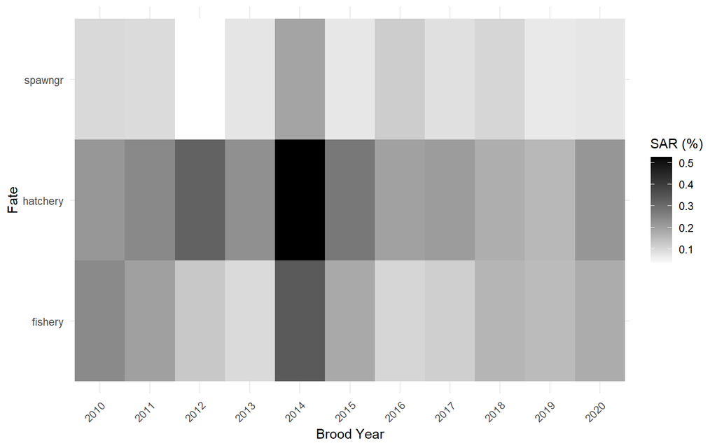

Figure 2: Smolt-adult return calculated collectively across brood year released and recovery fate.

**Tab 1**

Table 4: Recovery locations associated with a ‘hatchery’ fate in the filtered data, and the number of estimated recoveries (number_cwt_estimated) reported for each recovery location.

| recovery_location_code | name | latitude | longitude | psc_region | number_cwt_estimated |
| --- | --- | --- | --- | --- | --- |
| 3F10208^^031421^H | MARBLEMOUNT HATCHERY | 48.5223 | -121.4178 | SKAG | 18434.33 |
| 3F10107^^010406^H | KENDALL CR HATCHERY | 48.8973 | -122.1420 | NOWA | 8989.48 |
| 3F10107^^010273^H | SKOOKUM CR HATCHERY | 48.6713 | -122.1437 | NOWA | 8855.77 |
| 3F10308^^070943^H | WALLACE R HATCHERY | 47.8674 | -121.7170 | NPS | 43.00 |
| 3F10308^^050135^R | STILLAGUAMISH R -NF | 48.2038 | -122.1262 | NPS | 31.77 |
| 3F10208^^030435^R | BAKER R 03.0435 | 48.5339 | -121.7353 | SKAG | 5.50 |
| 3F10107^^030017^H | SAMISH HATCHERY | 48.5649 | -122.3315 | NOWA | 4.00 |
| 3F42001^^490138^H02 | CHIEF JOSEPH HATCHERY | NA | NA | UPCR | 3.29 |
| 3F10412^^160005^H | GEORGE ADAMS HATCHERY | 47.3013 | -123.1818 | HOOD | 2.04 |
| 3F10707^^020065^H | GLENWOOD SPRINGS | 48.6821 | -122.8822 | NOWA | 1.02 |
| 3F21902^^240460^H | NEMAH HATCHERY | 46.5030 | -123.8411 | WILP | 1.02 |
| 3F10513^^150048^H | MINTER CR HATCHERY | 47.3726 | -122.7026 | SPS | 1.01 |

**Tab 2**

Table 5: Recovery locations associated with a ‘spawngr’ fate in the filtered data, and the number of estimated recoveries (number_cwt_estimated) reported for each recovery location.

| recovery_location_code | name | latitude | longitude | psc_region | number_cwt_estimated |
| --- | --- | --- | --- | --- | --- |
| 3F10107^^010246^R | NOOKSACK -SF 01.0246 | 48.80910 | -122.2021 | NOWA | 6602.55 |
| 3F10208^^031411^R | CASCADE R 03.1411 | 48.52420 | -121.4292 | SKAG | 1510.85 |
| 3F10107^^010120DR | KENDALL SLU 01.0120D | NA | NA | NOWA | 862.28 |
| 3F10208^^031421^R | CLARK CR 03.1421 | 48.52680 | -121.4109 | SKAG | 737.40 |
| 3F10107^^010120^R02 | NOOKSACK R -NF 01.0120 | 48.83530 | -122.1541 | NOWA | 464.30 |
| 3F10208^^031411^R01 | CASCADE R -LOWER 03.1411 | 48.52420 | -121.4292 | SKAG | 437.33 |
| 3F10107^^010406^R | KENDALL CR 01.0406 | 48.88690 | -122.1475 | NOWA | 277.55 |
| 3F10107^^010120^R | NOOKSACK R 01.0120 | 48.77120 | -122.5982 | NOWA | 230.76 |
| 3F10107^^010290^R | UNNAMED CR 01.0290 | 48.63520 | -122.1160 | NOWA | 229.11 |
| 3F10308^^050135^R | STILLAGUAMISH R -NF | 48.20380 | -122.1262 | NPS | 212.11 |
| 3F10107^^010472^R | THOMPSON CR 01.0472 | 48.87880 | -121.9133 | NOWA | 196.66 |
| 3F10107^^010437^R | CANYON CR 01.0437 | 48.90580 | -121.9880 | NOWA | 190.07 |
| 3F10107^^010264^R | HUTCHINSON C 01.0264 | 48.70700 | -122.1779 | NOWA | 156.87 |
| 3F10107^^010273^R | SKOOKUM CR 01.0273 | 48.67050 | -122.1404 | NOWA | 152.56 |
| 3F10107^^010415^R | MAPLE CR 01.0415 | 48.91210 | -122.0779 | NOWA | 142.22 |
| 3F10208^^030176^R | SKAGIT R 03.0176 | 48.38740 | -122.3661 | SKAG | 133.66 |
| 3F10208^^031425^R | BOULDER CR 03.1425 | 48.51770 | -121.3646 | SKAG | 132.64 |
| 3F10208^^031412^R | JORDAN CR 03.1412 | 48.52190 | -121.4210 | SKAG | 111.81 |
| 3F10107^^010295^R | DEER CR 01.0295 | 48.61010 | -122.0940 | NOWA | 109.75 |
| 3F10208^^030377^R | GRANDY CR 03.0377 | 48.51830 | -121.8793 | SKAG | 107.74 |
| 3F10107^^010352^R | MOSQUITO LK C 1.0352 | 48.79030 | -122.1205 | NOWA | 81.87 |
| 3F10107^^010285^R | CAVANAUGH CR 01.0285 | 48.64690 | -122.1193 | NOWA | 80.89 |
| 3F10107^^010339^R | NOOKSACK -MF 01.0339 | 48.83430 | -122.1541 | NOWA | 70.60 |
| 3F10107^^010120BR | BEAR SLOUGH 01.0120B | NA | NA | NOWA | 67.81 |
| 3F10208^^031774^R | BACON CR 03.1774 | 48.58560 | -121.3936 | SKAG | 67.33 |
| 3F10107^^010291^R | UNNAMED CR 01.0291 | 48.63420 | -122.1164 | NOWA | 65.66 |
| 3F10107^^010294^R | ROARING CR 01.0294 | 48.61170 | -122.0958 | NOWA | 54.04 |
| 3F10208^^031411^R03 | CASCADE R -UPPER 03.1411 | 48.52420 | -121.4292 | SKAG | 52.95 |
| 3F10107^^010120ZR02 | NOOKSACK R-NF &TRIBS | NA | NA | NOWA | 46.96 |
| 3F10208^^031750^R | DIOBSUD CR 03.1750 | 48.55900 | -121.4111 | SKAG | 43.71 |
| 3F10107^^010120ER | WICK SLOUGH 01.0120E | NA | NA | NOWA | 42.93 |
| 3F10107^^010424^R | BOULDER CR 01.0424 | 48.92470 | -122.0361 | NOWA | 34.65 |
| 3F10208^^030299^R | DAY CR 03.0299 | 48.51920 | -122.0653 | SKAG | 34.28 |
| 3F10208^^030673^R | SAUK R 03.0673 | 48.48170 | -121.6038 | SKAG | 32.45 |
| 3F10208^^031079^R | DAN CR 03.1079 | 48.29790 | -121.5499 | SKAG | 27.95 |
| 3F10107^^010270^R | SAXON CR 01.0270 | NA | NA | NOWA | 23.94 |
| 3F10107^^010394AR | UNNAMED CR 1.0394A | NA | NA | NOWA | 23.51 |
| 3F10107^^010292^R | PLUMBAGO CR 01.0292 | 48.62250 | -122.1107 | NOWA | 21.21 |
| 3F10107^^010283^R | EDFRO CR 01.0283 | 48.66090 | -122.1254 | NOWA | 20.19 |
| 3F10107^^010394^R | RACEHORSE CR 01.0394 | 48.88860 | -122.1443 | NOWA | 14.52 |
| 3F10308^^050001^R02 | STILLAGUAMISH R -SF | 48.20480 | -122.1262 | NPS | 13.50 |
| 3F10107^^010435^R | NOOKSACK TRB 01.0435 | 48.92080 | -122.0147 | NOWA | 12.58 |
| 3F10107^^01-009^R | COREY SL 01.-009 | 48.92040 | -122.0548 | NOWA | 12.05 |
| 3F10107^^01-013^R | CORNELL SL 01.-013 | 48.89979 | -121.9731 | NOWA | 12.05 |
| 3F10107^^010468^R | GALLOP CR 01.0468 | 48.89440 | -121.9423 | NOWA | 11.67 |
| 3F10208^^031346^R | ILLABOT CR 03.1346 | 48.49620 | -121.5300 | SKAG | 11.08 |
| 3F10107^^010353^R | UNNAMED CR 01.0353 | 48.78750 | -122.1210 | NOWA | 10.11 |
| 3F10107^^010464^R | CORNELL CR 01.0464 | 48.89870 | -121.9679 | NOWA | 9.26 |
| 3F10107^^010490^R | BOYD CR 01.0490 | 48.51020 | -121.8925 | NOWA | 9.26 |
| 3F10107^^010284^R | UNNAMED CR 01.0284 | 48.64860 | -122.1216 | NOWA | 8.89 |
| 3F10308^^070940^R | WALLACE R 07.0940 | 47.85910 | -121.7938 | NPS | 5.58 |
| 3F10107^^030005^R | SAMISH R 03.0005 | 48.55510 | -122.4558 | NOWA | 5.16 |
| 3F10107^^010392AR | KENNEY SLU 01.0392A | NA | NA | NOWA | 4.02 |
| 3F10107^^010466AR | BOTTIGER SLU 01.0466A | NA | NA | NOWA | 3.43 |
| 3F10107^^010340^R | CANYON CR 01.0340 | 48.83200 | -122.1428 | NOWA | 2.66 |
| 3F10107^^010402^R | COAL CR 01.0402 | 48.88090 | -122.1513 | NOWA | 2.66 |
| 3F10107^^01-005^R | LEAVITTS SL 01.-005 | 48.90403 | -122.1341 | NOWA | 2.41 |
| 3F10107^^01-007^R | MAPLE CREEK SIDE CHANNEL | 48.91192 | -122.0792 | NOWA | 0.00 |

**Tab 3**

Table 6: Recovery locations associated with a ‘fishery’ fate in the filtered data, and the number of estimated recoveries (number_cwt_estimated) reported for each recovery location.

| recovery_location_code | name | latitude | longitude | psc_region | number_cwt_estimated |
| --- | --- | --- | --- | --- | --- |
| 3F10208^^030176^R | SKAGIT R 03.0176 | 48.3874 | -122.3661 | SKAG | 8975.92 |
| 3F10107^^010120^R | NOOKSACK R 01.0120 | 48.7712 | -122.5982 | NOWA | 3089.87 |
| 3F10208^^031411^R | CASCADE R 03.1411 | 48.5242 | -121.4292 | SKAG | 815.51 |
| 2MS01P127^^^^^^^000 | NWTR P127-000 | NA | NA | NA | 485.41 |
| 3M10107^^B | BELLINGHAM BAY 7B | NA | NA | NOWA | 437.61 |
| 2MS01M403^^^^^^^000 | NWTR M403-000 | NA | NA | NA | 404.71 |
| 3M32404 | MARINE AREA 4 | NA | NA | NWC | 343.81 |
| 2MS02P123^^^^^^^000 | SWTR P123-000 | NA | NA | NA | 266.67 |
| 2MS02M23B^^^^^^^000 | SWTR M23B-000 | NA | NA | NA | 266.38 |
| 1M1NW113^41 | AK M 1 NW 113-41 | NA | NA | SEAK | 263.00 |
| 3M10107^^C | SAMISH BAY 7C | NA | NA | NOWA | 239.65 |
| 2MSNGP013CP^MUDG^02 | NSGSPTCP MUDG(13-2) | 49.9898 | -125.1919 | NA | 205.86 |
| 2MSSVM23B | SWVISPT M23B | NA | NA | NA | 205.79 |
| 2MS5SP124^^^^^^^000 | 5NWCVIS P124-000 | NA | NA | NA | 204.24 |
| 2MS24P020BECH^BY^05 | JFSPT BECH BY(20-5) | 48.3244 | -123.6128 | NA | 183.63 |
| 2MN06P101^^^^^^^000 | NTR P101-000 | NA | NA | NA | 151.28 |
| 2MS5SP024^^^^^^^000 | 5NWCVIS P024-000 | NA | NA | NA | 139.64 |
| 2MS02M111^^^^^^^000 | SWTR M111-000 | NA | NA | NA | 137.71 |
| 2MS24P020OTTE^PT^05 | JFSPT OTTE PT(20-5) | 48.3569 | -123.8222 | NA | 137.31 |
| 3M11107^^872178 | GENERAL - AREA 7 | NA | NA | NOWA | 132.34 |
| 3M32404^^B | 4B -TREATY TROLL | NA | NA | JUAN | 130.59 |
| 2MSNGP014KITT^BE^13 | NSGSPTKITT BE(14-13) | 49.7915 | -124.9870 | NA | 125.99 |
| 2MSSVM23BSWAL^RK^07 | SV M23B SWAL RK(23-7) | 48.9255 | -125.2224 | NA | 125.84 |
| 2MSSGP017ENTR^IS^12 | SSGSPTENTR IS(17-12) | 49.2089 | -123.8094 | NA | 124.30 |
| 2MSSVP123BIG^BK^^08 | SWVISPBIG BK(123-8) | 48.6667 | -125.6667 | NA | 115.83 |
| 2MS24M19BMACC^PT^01 | 24 M19B MACC PT(19-1) | 48.4169 | -123.4100 | NA | 113.04 |
| 2MS24M19BOAK^BY^^04 | 24 M19B OAK BY(19-4) | 49.4311 | -123.3003 | NA | 109.08 |
| 2MS24M19BVICTORI^01 | 24 M19B VICTORI(19-1) | 48.4211 | -123.3928 | NA | 105.01 |
| 2MSNGP014FREN^CK | NSGSPTFREN CK(P014) | 49.3486 | -124.3611 | NA | 104.62 |
| 3F10107^^010045^R | CALIFORNIA CR 1.0045 | 48.9626 | -122.7324 | NOWA | 103.96 |

[output cut: 483 more lines]

**Tab A**

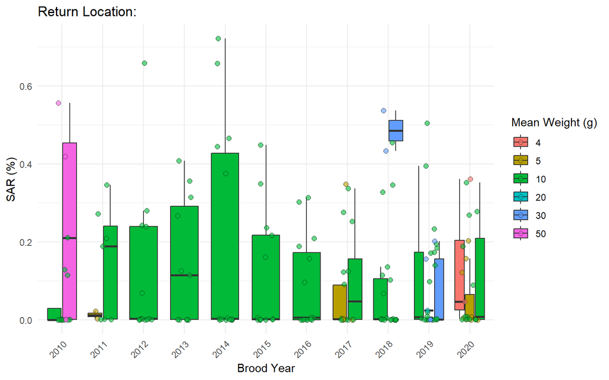

Figure 3: Smolt-adult return calcualted from the raw release and return data across brood years and mean weight release groups.

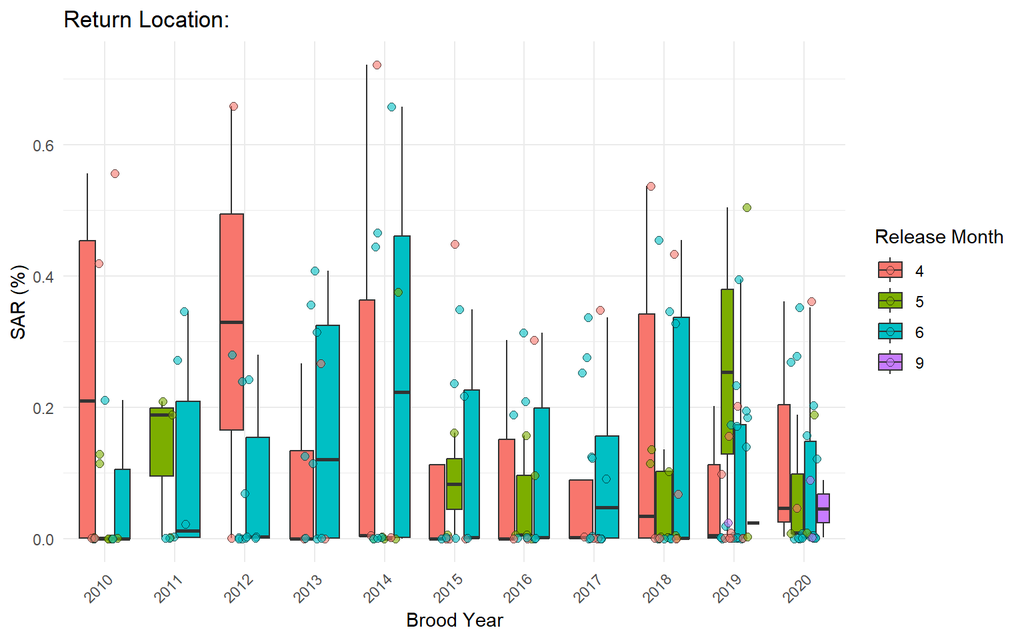

Figure 4: Smolt-adult return calcualted from the raw release and return data across brood years and release month.

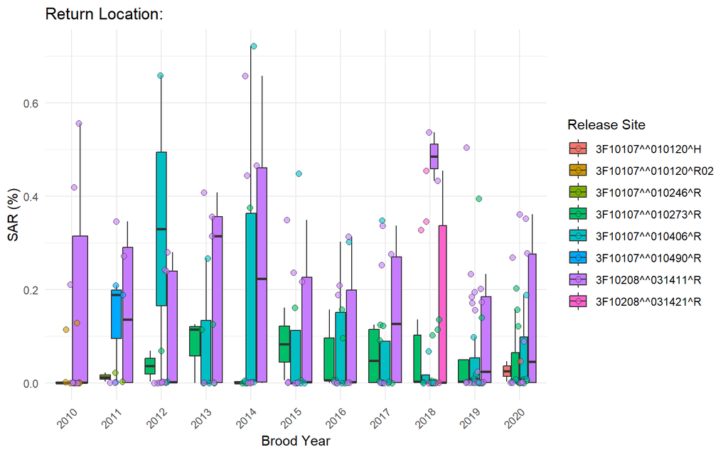

Figure 5: Smolt-adult return calcualted from the raw release and return data across brood years and release sites.

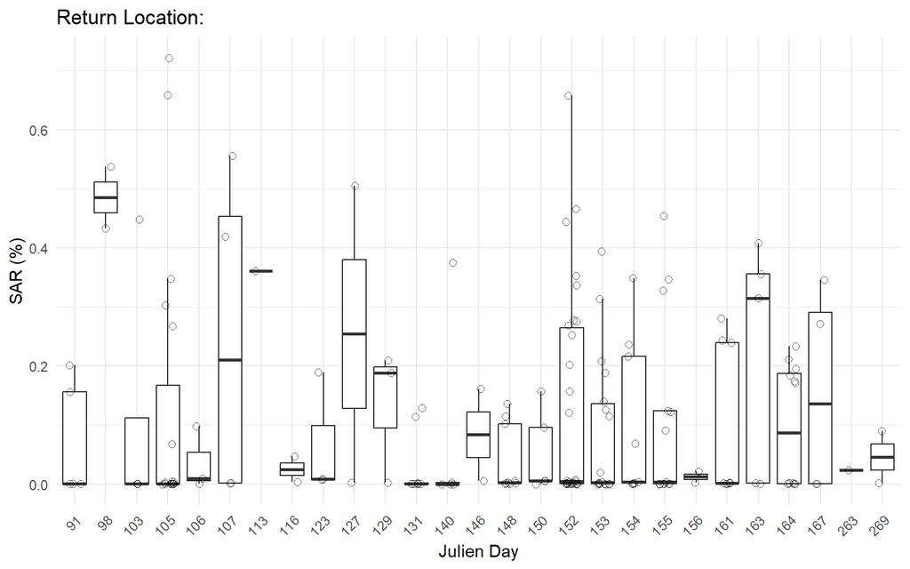

Figure 6: Smolt-adult return calcualted from the raw release and return data across brood years and julian days.

**Tab B**

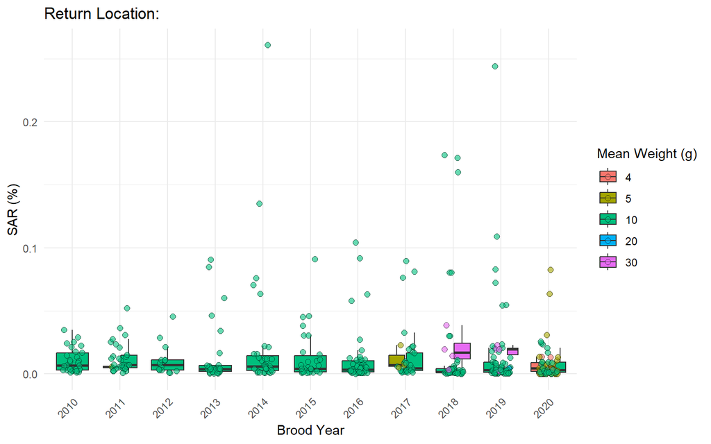

Figure 7: Smolt-adult return calcualted from the raw release and return data across brood years and mean weight release groups.

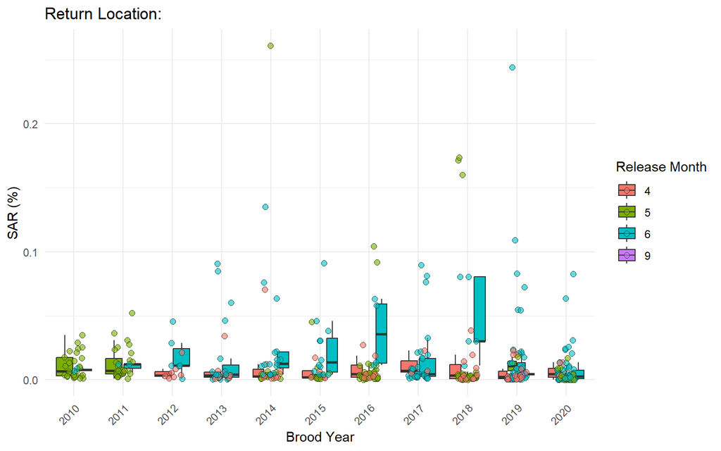

Figure 8: Smolt-adult return calcualted from the raw release and return data across brood years and release month.

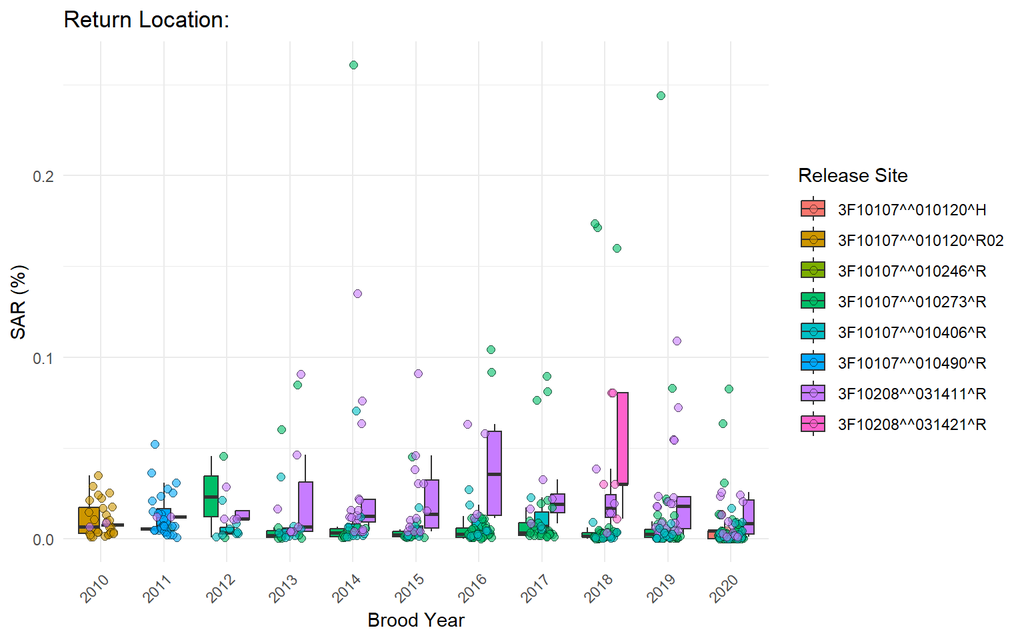

Figure 9: Smolt-adult return calcualted from the raw release and return data across brood years and release sites.

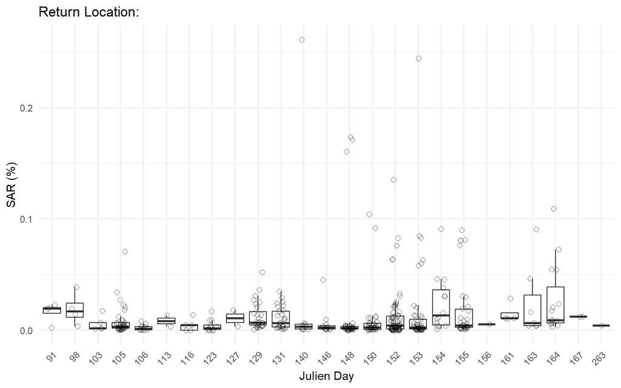

Figure 10: Smolt-adult return calcualted from the raw release and return data across brood years and julian days.

**Tab C**

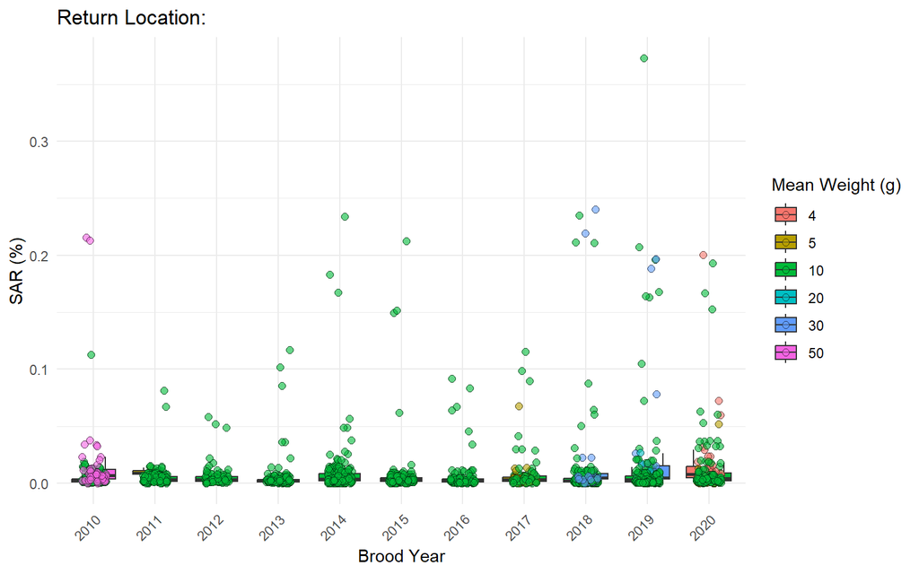

Figure 11: Smolt-adult return calcualted from the raw release and return data across brood years and mean weight release groups.

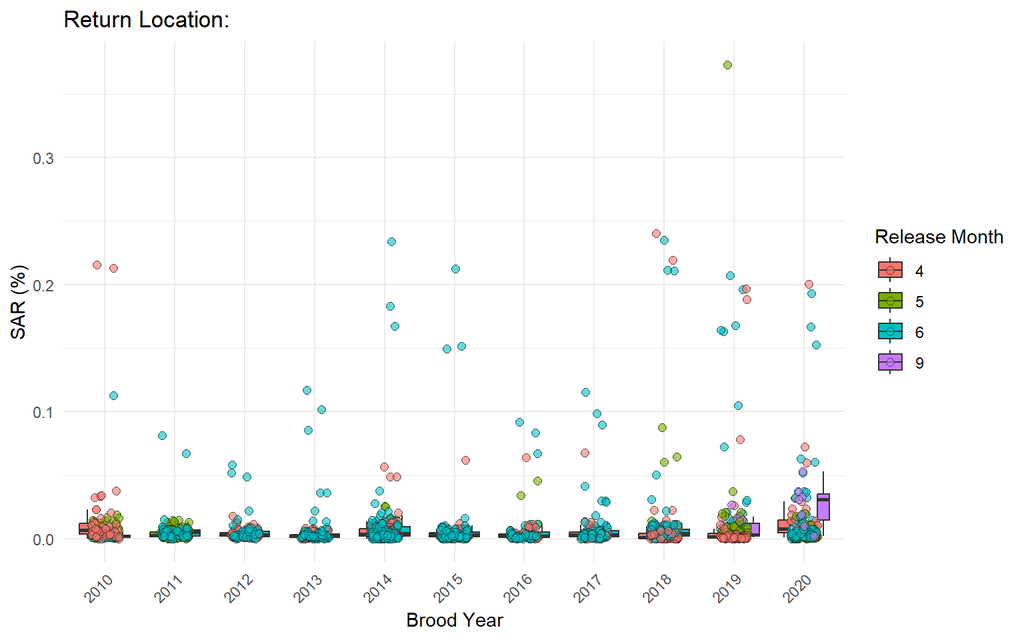

Figure 12: Smolt-adult return calcualted from the raw release and return data across brood years and release month.

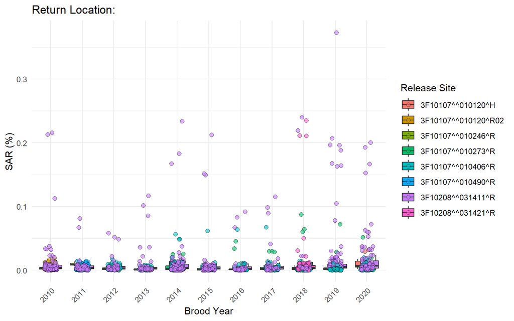

Figure 13: Smolt-adult return calcualted from the raw release and return data across brood years and release sites.

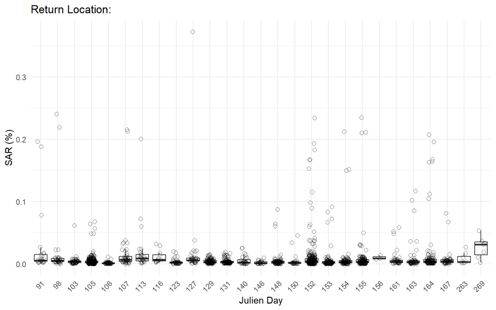

Figure 14: Smolt-adult return calcualted from the raw release and return data across brood years and julian days.

**Tab A**

Table 7: Smolt-adult return calculated across brood years, mean weight-at-release, and time at release.

| species | release_location_code | recovery_location_code | month | jday | avg_weight | event_released | sar |
| --- | --- | --- | --- | --- | --- | --- | --- |
| **2010** |  |  |  |  |  |  |  |
| 1 | 3F10208^^031411^R | 3F10208^^031421^H | 4 | 107 | 50 | 66928 | 0.0041909 |
| 1 | 3F10208^^031411^R | 3F10208^^031421^H | 4 | 107 | 50 | 72268 | 0.0055575 |
| 1 | 3F10208^^031411^R | 3F10308^^070943^H | 4 | 107 | 50 | 72268 | 0.0000141 |
| 1 | 3F10107^^010120^R02 | 3F10107^^010406^H | 5 | 131 | 10 | 193637 | 0.0012937 |
| 1 | 3F10107^^010120^R02 | 3F10208^^031421^H | 5 | 131 | 10 | 193637 | 0.0000052 |
| 1 | 3F10107^^010120^R02 | 3F10107^^010273^H | 5 | 131 | 10 | 200065 | 0.0000100 |
| 1 | 3F10107^^010120^R02 | 3F10107^^010406^H | 5 | 131 | 10 | 200065 | 0.0011461 |
| 1 | 3F10107^^010120^R02 | 3F10208^^031421^H | 5 | 131 | 10 | 200065 | 0.0000050 |
| 1 | 3F10107^^010120^R02 | 3F10412^^160005^H | 5 | 131 | 10 | 200065 | 0.0000052 |
| 1 | 3F10208^^031411^R | 3F10208^^031421^H | 6 | 164 | 10 | 251810 | 0.0021103 |
| 1 | 3F10208^^031411^R | 3F10308^^070943^H | 6 | 164 | 10 | 251810 | 0.0000041 |
| **2011** |  |  |  |  |  |  |  |
| 1 | 3F10107^^010490^R | 3F10107^^010273^H | 5 | 129 | 10 | 200456 | 0.0000249 |
| 1 | 3F10107^^010490^R | 3F10107^^010406^H | 5 | 129 | 10 | 200456 | 0.0018840 |
| 1 | 3F10107^^010490^R | 3F10107^^010406^H | 5 | 129 | 10 | 201745 | 0.0020927 |
| 1 | 3F10107^^010246^R | 3F10107^^010273^H | 6 | 156 | 5 | 32388 | 0.0002186 |
| 1 | 3F10107^^010246^R | 3F10107^^010406^H | 6 | 156 | 5 | 32388 | 0.0000315 |
| 1 | 3F10208^^031411^R | 3F10208^^031421^H | 6 | 167 | 10 | 180435 | 0.0027183 |
| 1 | 3F10208^^031411^R | 3F10208^^031421^H | 6 | 167 | 10 | 180435 | 0.0034616 |
| **2012** |  |  |  |  |  |  |  |
| 1 | 3F10107^^010406^R | 3F10107^^010406^H | 4 | 105 | 10 | 200479 | 0.0065883 |
| 1 | 3F10107^^010406^R | 3F10208^^031421^H | 4 | 105 | 10 | 200479 | 0.0000101 |
| 1 | 3F10107^^010273^R | 3F10107^^010273^H | 6 | 154 | 10 | 154847 | 0.0006918 |
| 1 | 3F10107^^010273^R | 3F10107^^010406^H | 6 | 154 | 10 | 154847 | 0.0000334 |
| 1 | 3F10208^^031411^R | 3F10208^^031421^H | 6 | 161 | 10 | 205162 | 0.0028061 |
| 1 | 3F10208^^031411^R | 3F10308^^070943^H | 6 | 161 | 10 | 205162 | 0.0000197 |
| 1 | 3F10208^^031411^R | 3F10208^^031421^H | 6 | 161 | 10 | 203613 | 0.0024306 |
| 1 | 3F10208^^031411^R | 3F10308^^070943^H | 6 | 161 | 10 | 203613 | 0.0000051 |
| 1 | 3F10208^^031411^R | 3F10107^^010406^H | 6 | 161 | 10 | 77500 | 0.0000132 |

[output cut: 131 more lines]

**Tab B**

Table 8: Smolt-adult return calculated across brood years, mean weight-at-release, and time at release.

| species | release_location_code | recovery_location_code | month | jday | avg_weight | event_released | sar |
| --- | --- | --- | --- | --- | --- | --- | --- |
| **2010** |  |  |  |  |  |  |  |
| 1 | 3F10107^^010120^R02 | 3F10107^^010120^R | 5 | 131 | 10 | 193637 | 0.0000650 |
| 1 | 3F10107^^010120^R02 | 3F10107^^010120^R02 | 5 | 131 | 10 | 193637 | 0.0003487 |
| 1 | 3F10107^^010120^R02 | 3F10107^^010120DR | 5 | 131 | 10 | 193637 | 0.0001311 |
| 1 | 3F10107^^010120^R02 | 3F10107^^010246^R | 5 | 131 | 10 | 193637 | 0.0000636 |
| 1 | 3F10107^^010120^R02 | 3F10107^^010339^R | 5 | 131 | 10 | 193637 | 0.0000254 |
| 1 | 3F10107^^010120^R02 | 3F10107^^010353^R | 5 | 131 | 10 | 193637 | 0.0000283 |
| 1 | 3F10107^^010120^R02 | 3F10107^^010406^R | 5 | 131 | 10 | 193637 | 0.0000943 |
| 1 | 3F10107^^010120^R02 | 3F10107^^010415^R | 5 | 131 | 10 | 193637 | 0.0001695 |
| 1 | 3F10107^^010120^R02 | 3F10107^^010435^R | 5 | 131 | 10 | 193637 | 0.0000282 |
| 1 | 3F10107^^010120^R02 | 3F10107^^010437^R | 5 | 131 | 10 | 193637 | 0.0001751 |
| 1 | 3F10107^^010120^R02 | 3F10107^^010472^R | 5 | 131 | 10 | 193637 | 0.0002231 |
| 1 | 3F10107^^010120^R02 | 3F10208^^030176^R | 5 | 131 | 10 | 193637 | 0.0001020 |
| 1 | 3F10107^^010120^R02 | 3F10308^^050135^R | 5 | 131 | 10 | 193637 | 0.0000130 |
| 1 | 3F10107^^010120^R02 | 3F10107^^010120^R | 5 | 131 | 10 | 200065 | 0.0000355 |
| 1 | 3F10107^^010120^R02 | 3F10107^^010120^R02 | 5 | 131 | 10 | 200065 | 0.0002911 |
| 1 | 3F10107^^010120^R02 | 3F10107^^010120BR | 5 | 131 | 10 | 200065 | 0.0000231 |
| 1 | 3F10107^^010120^R02 | 3F10107^^010120DR | 5 | 131 | 10 | 200065 | 0.0002405 |
| 1 | 3F10107^^010120^R02 | 3F10107^^010120ER | 5 | 131 | 10 | 200065 | 0.0000355 |
| 1 | 3F10107^^010120^R02 | 3F10107^^010120ZR02 | 5 | 131 | 10 | 200065 | 0.0001066 |
| 1 | 3F10107^^010120^R02 | 3F10107^^010246^R | 5 | 131 | 10 | 200065 | 0.0000115 |
| 1 | 3F10107^^010120^R02 | 3F10107^^010339^R | 5 | 131 | 10 | 200065 | 0.0000364 |
| 1 | 3F10107^^010120^R02 | 3F10107^^010352^R | 5 | 131 | 10 | 200065 | 0.0000277 |
| 1 | 3F10107^^010120^R02 | 3F10107^^010353^R | 5 | 131 | 10 | 200065 | 0.0000111 |
| 1 | 3F10107^^010120^R02 | 3F10107^^010406^R | 5 | 131 | 10 | 200065 | 0.0000201 |
| 1 | 3F10107^^010120^R02 | 3F10107^^010415^R | 5 | 131 | 10 | 200065 | 0.0001449 |
| 1 | 3F10107^^010120^R02 | 3F10107^^010435^R | 5 | 131 | 10 | 200065 | 0.0000355 |
| 1 | 3F10107^^010120^R02 | 3F10107^^010437^R | 5 | 131 | 10 | 200065 | 0.0002116 |
| 1 | 3F10107^^010120^R02 | 3F10107^^010472^R | 5 | 131 | 10 | 200065 | 0.0002515 |
| 1 | 3F10208^^031411^R | 3F10208^^031411^R | 6 | 164 | 10 | 251810 | 0.0000869 |

[output cut: 427 more lines]

**Tab C**

Table 9: Smolt-adult return calculated across brood years, mean weight-at-release, and time at release.

| species | release_location_code | recovery_location_code | month | jday | avg_weight | event_released | sar |
| --- | --- | --- | --- | --- | --- | --- | --- |
| **2010** |  |  |  |  |  |  |  |
| 1 | 3F10208^^031411^R | 3M11105^^872465 | 4 | 107 | 50 | 66928 | 0.0000397 |
| 1 | 3F10208^^031411^R | 3M11106^^872423 | 4 | 107 | 50 | 66928 | 0.0000306 |
| 1 | 3F10208^^031411^R | 3M11106^^872557 | 4 | 107 | 50 | 66928 | 0.0000654 |
| 1 | 3F10208^^031411^R | 3M11107^^872098 | 4 | 107 | 50 | 66928 | 0.0000562 |
| 1 | 3F10208^^031411^R | 3M11107^^872178 | 4 | 107 | 50 | 66928 | 0.0001315 |
| 1 | 3F10208^^031411^R | 3M11107^^872535 | 4 | 107 | 50 | 66928 | 0.0000000 |
| 1 | 3F10208^^031411^R | 3M11107^^872542 | 4 | 107 | 50 | 66928 | 0.0000000 |
| 1 | 3F10208^^031411^R | 3M112082^872209 | 4 | 107 | 50 | 66928 | 0.0000808 |
| 1 | 3F10208^^031411^R | 3M11309^^872180 | 4 | 107 | 50 | 66928 | 0.0000702 |
| 1 | 3F10208^^031411^R | 3M11309^^872382 | 4 | 107 | 50 | 66928 | 0.0000478 |
| 1 | 3F10208^^031411^R | 3M11411^^872563 | 4 | 107 | 50 | 66928 | 0.0001179 |
| 1 | 3F10208^^031411^R | 3F10208^^030176^R | 4 | 107 | 50 | 66928 | 0.0002279 |
| 1 | 3F10208^^031411^R | 3F10208^^031411^R | 4 | 107 | 50 | 66928 | 0.0001158 |
| 1 | 3F10208^^031411^R | 3F10208^^031411^R01 | 4 | 107 | 50 | 66928 | 0.0003773 |
| 1 | 3F10208^^031411^R | 3F10208^^030176^R | 4 | 107 | 50 | 66928 | 0.0021557 |
| 1 | 3F10208^^031411^R | 1M1NW113^4103^^MS | 4 | 107 | 50 | 66928 | 0.0003336 |
| 1 | 3F10208^^031411^R | 2MS24M19BCONS^BK^03 | 4 | 107 | 50 | 66928 | 0.0000790 |
| 1 | 3F10208^^031411^R | 2MS24M19BPEDD^BY^05 | 4 | 107 | 50 | 66928 | 0.0001620 |
| 1 | 3F10208^^031411^R | 2MS24M19BVICT^BW^03 | 4 | 107 | 50 | 66928 | 0.0003239 |
| 1 | 3F10208^^031411^R | 2MS24P020BECH^BY^05 | 4 | 107 | 50 | 66928 | 0.0002044 |
| 1 | 3F10208^^031411^R | 2MS24P020OTTE^PT^05 | 4 | 107 | 50 | 66928 | 0.0001028 |
| 1 | 3F10208^^031411^R | 2MS24P020TWENTY | 4 | 107 | 50 | 66928 | 0.0003398 |
| 1 | 3F10208^^031411^R | 2MSNGP013CP^MUDG^02 | 4 | 107 | 50 | 66928 | 0.0000571 |
| 1 | 3F10208^^031411^R | 2MSNVP027PR^ALIC^08 | 4 | 107 | 50 | 66928 | 0.0000356 |
| 1 | 3F10208^^031411^R | 2MSSVM23ANAHM^BY^02 | 4 | 107 | 50 | 66928 | 0.0002311 |
| 1 | 3F10208^^031411^R | 2MSSVM23BBARK^SD^08 | 4 | 107 | 50 | 66928 | 0.0000947 |
| 1 | 3F10208^^031411^R | 2MSSVM23BSWAL^RK^07 | 4 | 107 | 50 | 66928 | 0.0000944 |
| 1 | 3F10208^^031411^R | 2MS01M403^^^^^^^000 | 4 | 107 | 50 | 66928 | 0.0000574 |
| 1 | 3F10208^^031411^R | 2MS01P127^^^^^^^000 | 4 | 107 | 50 | 66928 | 0.0000574 |

[output cut: 1909 more lines]

SAR Model Fit

Smolt-adult survival (SAS) represents the survival of a release group when considering all of their possible fates. The “success” of a program will depend on how well the intended fate of those fish matches up with the observed proportion-at-fate. Here, we take release and return data from above and use these data collectively to calculate SAS as the number of fish that were recovered divided by the number released.

[output not shown]

Signif. codes: 0 <= '***' < 0.001 < '**' < 0.01 < '*' < 0.05  
Adjusted R-squared: 0.569, Deviance explained 0.794  
-REML : -458.741, Scale est: 238.617, N: 118

**Tab 1**

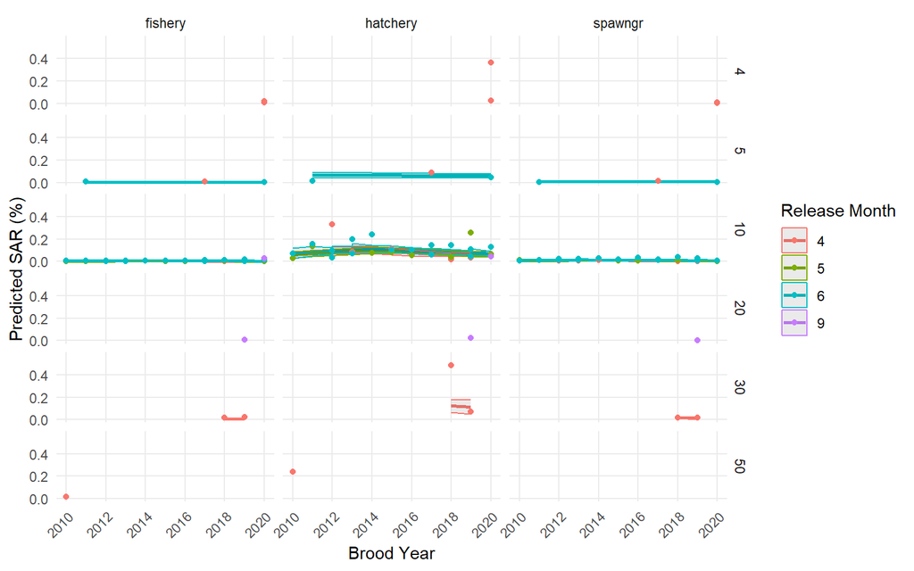

Figure 15: Predicted smolt-adult return generated from the model fit across fate, brood years, mean weight release groups, and release month.

**Tab 2**

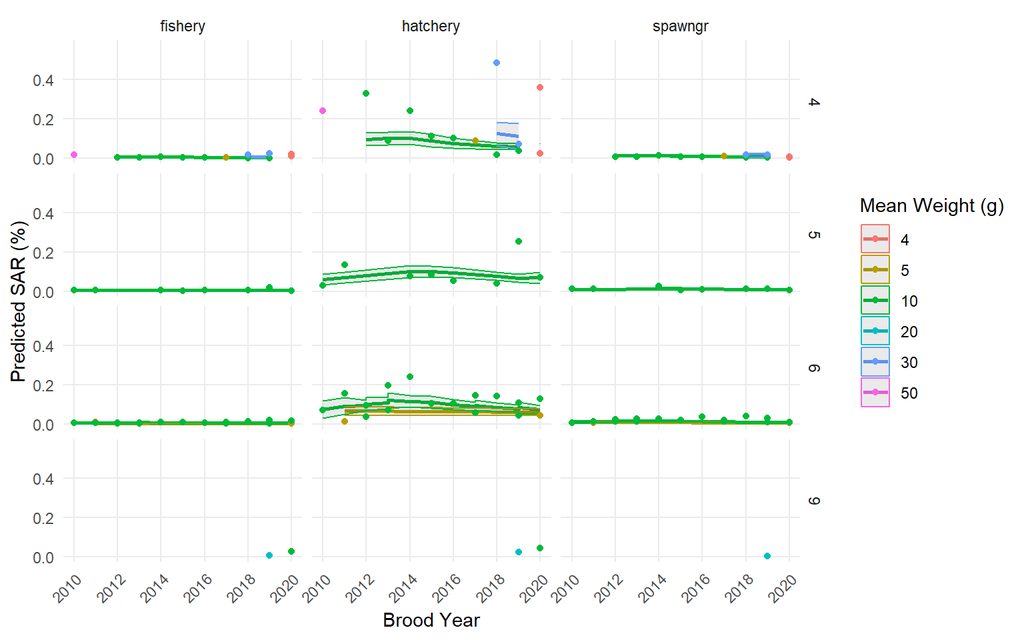

Figure 16: Predicted smolt-adult return generated from the model fit across fate, brood years, mean weight release groups, and release month.

**Tab 3**

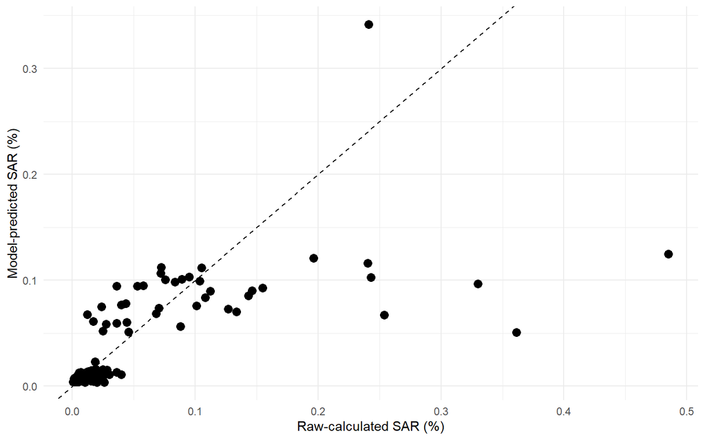

Figure 17: Raw-calculated vs. Model-predicted smolt-adult return generated from the model fit.

**Tab 4**

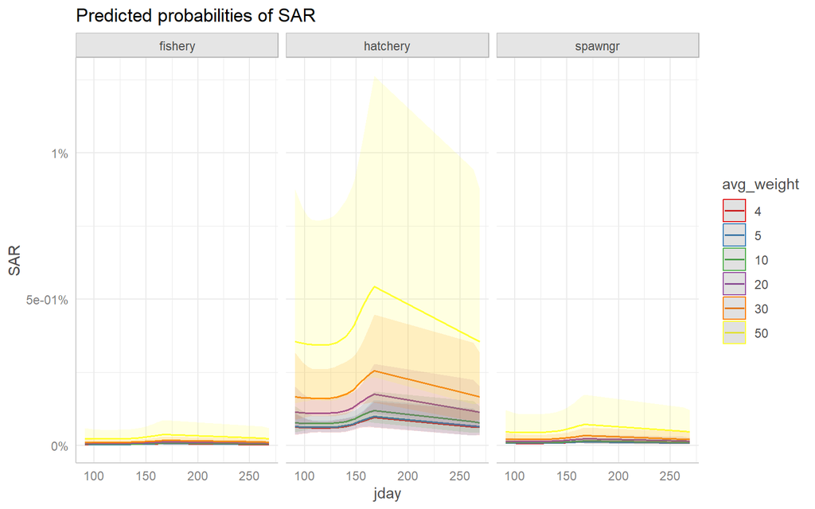

Figure 18: Marginal effects from the model fit showing how combined changes in mean weight at release and release timing (jday) affect smolt-adult-return across fates.

**Tab 1**

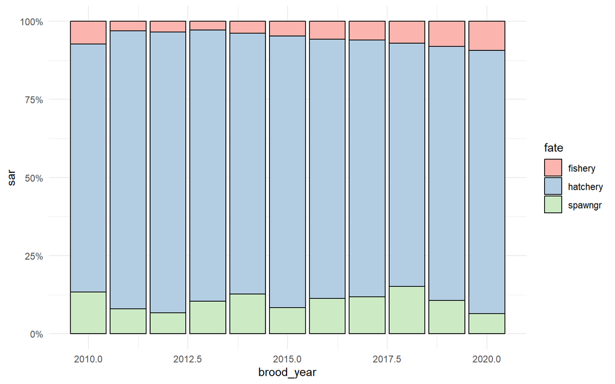

Figure 19: Proportion-at-fate of the calculated smolt-adult-return across brood years.

**Tab 2**

Smolt-adult-return (SAR)

Smolt-adult-return is calculated for each categorized fate (hatchery, fishery, and spawning ground) of paired release-recovery data. Below, fate is categorized based on fishery coding, and then fate-specific SARs are reported. These fate-specific SARs are then used below to: (1) fit predictive SAR models, and (2) calculate smolt-adult-survival (SAS). Fate is determined by the fishery coding reported for each recovery. Fishery codes range from 10-99, with some additional codes supplied for high seas fishery categories (800-812). We designate troll (10-19), net & seine (20-29), aboriginal (30-39), sport (40-49), treaty subsitence (56), test (60-69), and high seas (80-89, 800, 802-805, 812) fisheries recoveries as ‘fishery’ fates. In addition, we designate hatchery (50), fish trap (52), broodstock collections (53), and mixed broodstock collection/hatchery returns (57) recoveies as ‘hatchery’ fates, and we designate spawning ground (54) recoveries as ‘spawngr’ fates.

Paired release-recovery data are filtered for fates in this section, and used to calculate fate-specific SARs. We first report the recovery_location_codes present in the filtered data and the estimated recoveries (number_cwt_estimated) for each recovery location. There will likely be strays present, but we want to report a ‘return to rack’ for the hatchery to inform program performance and broodstock collection. Therefore, we filter these stray fish out here, and will re-incorporate them later in the summation of fate-specific SARs for calculation of SAS. Therefore, all hatchery SAR results will be for the list of location_codes categorized as hatchery_location_code in the metadata ruleset (Table 1). Hatcheries will often vary their rearing treatments to produce fish of different sizes at release or to release fish at different times of the season. Here, we aggregate the filtered hatchery data by the treatment variables size-at-release, release month, release site, and julian day of release. Below we report the SAR values shown in the figures above so the reader has access to the individual data points. Note that the figures report SAR in percentages, while the table values are raw values.

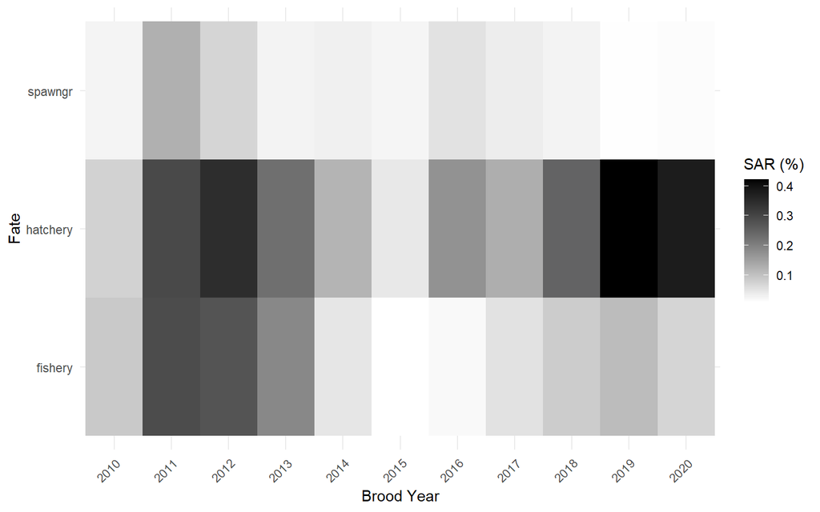

Figure 21: Smolt-adult return calculated collectively across brood year released and recovery fate.

**Tab 1**

Table 10: Recovery locations associated with a ‘hatchery’ fate in the filtered data, and the number of estimated recoveries (number_cwt_estimated) reported for each recovery location.

| recovery_location_code | name | latitude | longitude | psc_region | number_cwt_estimated |
| --- | --- | --- | --- | --- | --- |
| 3F42001^^260002^H02 | COWLITZ SALMON HATCHERY | 46.5113 | -122.6293 | LOCR | 13312.80 |
| 3F42001^^270168^H | LEWIS RIVER HATCHERY | 45.9370 | -122.6165 | LOCR | 4714.87 |
| 3F42001^^270002^H | KALAMA FALLS HATCHERY | 46.0160 | -122.7336 | LOCR | 2438.42 |
| 3F42001^^270168^R03 | MERWIN DAM FCF | 45.9570 | -122.5561 | LOCR | 181.13 |
| 3F42001^^270002^H03 | MODROW TRAP | 46.0447 | -122.8387 | LOCR | 25.05 |
| 3F42001^^270002^R | KALAMA R 27.0002 | 46.0338 | -122.8746 | LOCR | 17.00 |
| 3F42001^^270339^R | CEDAR CR 27.0339 | 45.9365 | -122.6174 | LOCR | 17.00 |
| 3F42001^^270339^R10 | CEDAR CR TRAP | 45.9365 | -122.6174 | LOCR | 4.00 |
| 5F33407^^H7^^^^^22 | WARM SPRINGS NFH | NA | NA | CECR | 3.78 |
| 5F33424^^H24^^^^21 | ROUND BUTTE TRAP | NA | NA | CECR | 3.03 |
| 3F42001^^360126^H | PRIEST RAPIDS HATCHERY | 46.6486 | -119.8967 | UPCR | 2.02 |
| 3F42001^^270017^H | FALLERT CR HATCHERY | 46.0459 | -122.8051 | LOCR | 2.00 |
| 3F42001^^470001^H02 | WELLS HATCHERY | 47.9468 | -119.8706 | UPCR | 1.01 |
| 3F10412^^160005^H | GEORGE ADAMS HATCHERY | 47.3013 | -123.1818 | HOOD | 1.01 |
| 5F33328^^H28^^^^21 | SOUTH SANTIAM HATCH | NA | NA | LOCR | 1.01 |
| 5F33558^^H58^^^^24 | LOOKINGGLASS CREEK TRAP | NA | NA | SNAK | 1.01 |
| 5F33201^^H1^^^^^21 | BONNEVILLE HATCHERY | NA | NA | LOCR | 1.01 |
| 3F42001^^280159^H | WASHOUGAL HATCHERY | 45.6518 | -122.1660 | LOCR | 1.01 |

**Tab 2**

Table 11: Recovery locations associated with a ‘spawngr’ fate in the filtered data, and the number of estimated recoveries (number_cwt_estimated) reported for each recovery location.

| recovery_location_code | name | latitude | longitude | psc_region | number_cwt_estimated |
| --- | --- | --- | --- | --- | --- |
| 3F42001^^270168^R | LEWIS R 27.0168 | 45.8504 | -122.7824 | LOCR | 539.12 |
| 3F42001^^270002^R | KALAMA R 27.0002 | 46.0338 | -122.8746 | LOCR | 497.39 |
| 3F42001^^260002^R | COWLITZ R 26.0002 | 46.0956 | -122.9155 | LOCR | 226.78 |
| 3F42001^^270168^R01 | LEWIS R -NF 27.0168 | 45.8504 | -122.7824 | LOCR | 51.36 |

**Tab 3**

Table 12: Recovery locations associated with a ‘fishery’ fate in the filtered data, and the number of estimated recoveries (number_cwt_estimated) reported for each recovery location.

| recovery_location_code | name | latitude | longitude | psc_region | number_cwt_estimated |
| --- | --- | --- | --- | --- | --- |
| 3F42001^^260002^R | COWLITZ R 26.0002 | 46.0956 | -122.9155 | LOCR | 2183.09 |
| 3M32202 | MARINE AREA 2 | NA | NA | GRAY | 696.13 |
| 3F42001^^270002^R | KALAMA R 27.0002 | 46.0338 | -122.8746 | LOCR | 669.16 |
| 5F33406^^R6^^^^^13 | BONN TO MCNARY DAM NET | NA | NA | CECR | 381.98 |
| 5F33207^^R7^^^^^13 | YOUNGS BAY NET ZONE 7 | 46.1917 | -123.8833 | LOCR | 304.77 |
| 1M1NW113^41 | AK M 1 NW 113-41 | NA | NA | SEAK | 294.83 |
| 2MN06P101^^^^^^^000 | NTR P101-000 | NA | NA | NA | 253.41 |
| 3F42001^^270002^R01 | KALAMA R BELOW FALLS | NA | NA | LOCR | 240.92 |
| 3F42001^^270168^R01 | LEWIS R -NF 27.0168 | 45.8504 | -122.7824 | LOCR | 233.18 |
| 3M32101 | MARINE AREA 1 | NA | NA | WILP | 232.46 |
| 2MSSVP123BIG^BK^^08 | SWVISPBIG BK(123-8) | 48.6667 | -125.6667 | NA | 178.01 |
| 3M32404 | MARINE AREA 4 | NA | NA | NWC | 157.65 |
| 3F42001^^300002^R | KLICKITAT R 30.0002 | 45.6914 | -121.2934 | CECR | 154.92 |
| 5F33203^^R209^^^12 | COL R OR SPORT SEC 9 | NA | NA | LOCR | 111.77 |
| 1M2PW212 | AK M 2 PW 212 | NA | NA | CEAK | 108.33 |
| 5F33203^^R110^^^12 | COL R WA SPORT SEC 10 | NA | NA | LOCR | 107.12 |
| 2MS02P123^^^^^^^000 | SWTR P123-000 | NA | NA | NA | 102.21 |
| 5F33271^^R71^^^^13 | TONGUE POINT ZONE 71 | NA | NA | LOCR | 97.63 |
| 2MS01M403^^^^^^^000 | NWTR M403-000 | NA | NA | NA | 95.04 |
| 5F33203^^R108^^^12 | COL R WA SPORT SEC 8 | NA | NA | LOCR | 92.95 |
| 5F33209^^R2^^^^^13 | COL R ZONE 2 NET | NA | NA | LOCR | 85.74 |
| 3M32303 | MARINE AREA 3 | NA | NA | NWC | 85.31 |
| 5M2222404O2404^^10 | NEWPORT AREA 4 | 44.6217 | -124.0533 | NOOR | 81.86 |
| 5F33203^^R106^^^12 | COL R WA SEC 6 | NA | NA | LOCR | 66.24 |
| 5F33307^^R4^^^^^14 | WILLAMETTE R LWR BTS | NA | NA | LOCR | 58.58 |
| 2MS01P127^^^^^^^000 | NWTR P127-000 | NA | NA | NA | 53.27 |
| 3M11105^^872465 | SEKIU | NA | NA | JUAN | 53.09 |
| 5M2221003O1003^^10 | GARIBALDI AREA 3 | 45.5550 | -123.9083 | NOOR | 52.21 |
| 5M2220202O0202^^10 | ASTORIA AREA 2 | 46.1950 | -123.8500 | NOOR | 52.18 |
| 5F33203^^R105^^^12 | COL R WA SPORT SEC 5 | NA | NA | LOCR | 50.38 |

[output cut: 163 more lines]

**Tab A**

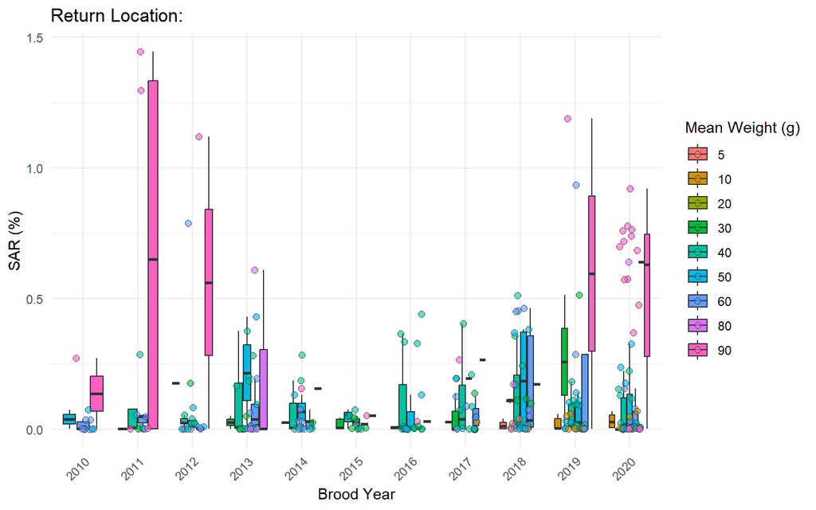

Figure 22: Smolt-adult return calcualted from the raw release and return data across brood years and mean weight release groups.

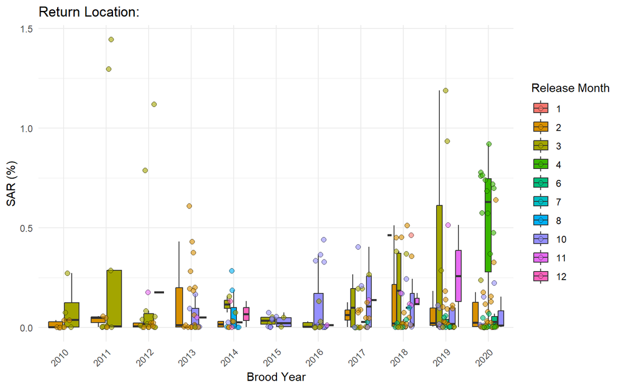

Figure 23: Smolt-adult return calcualted from the raw release and return data across brood years and release month.

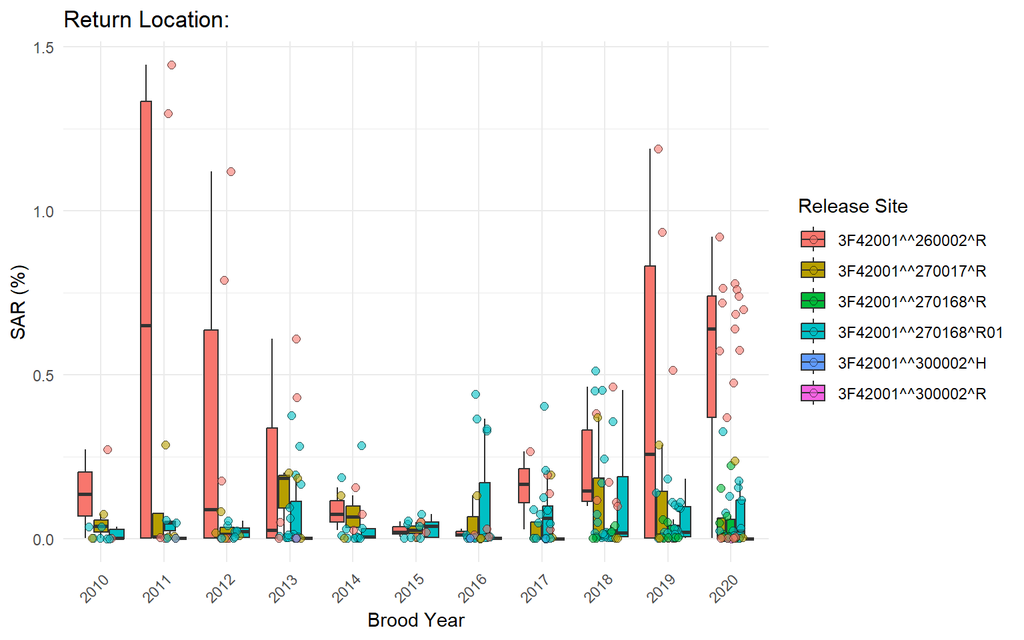

Figure 24: Smolt-adult return calcualted from the raw release and return data across brood years and release sites.

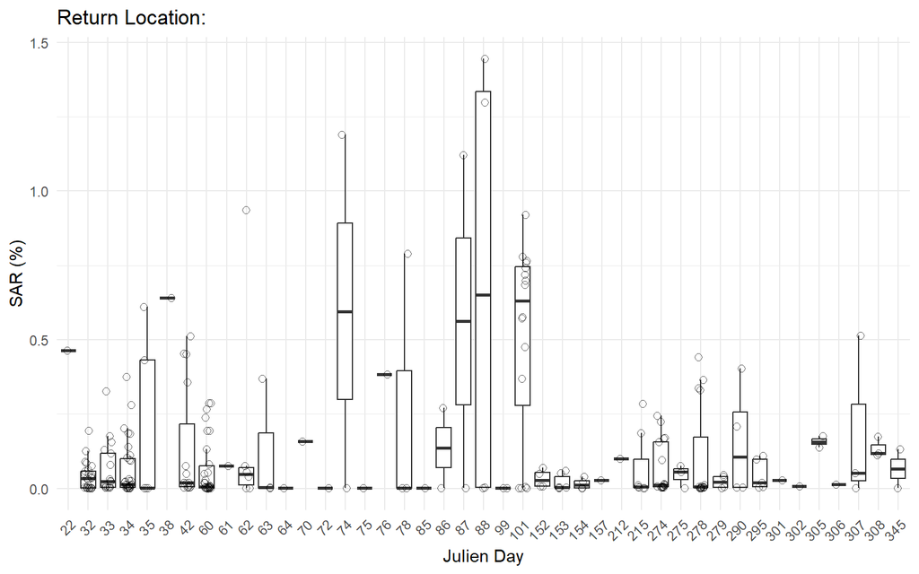

Figure 25: Smolt-adult return calcualted from the raw release and return data across brood years and julian days.

**Tab B**

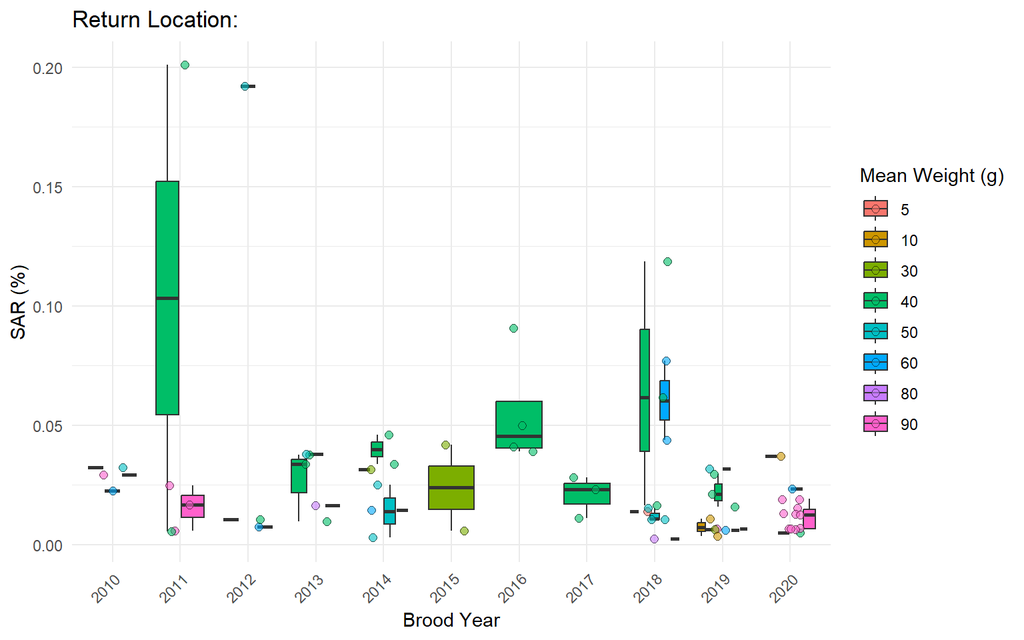

Figure 26: Smolt-adult return calcualted from the raw release and return data across brood years and mean weight release groups.

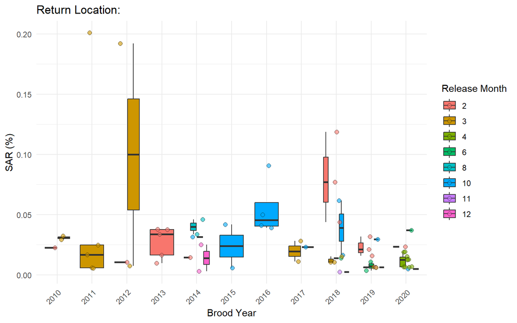

Figure 27: Smolt-adult return calcualted from the raw release and return data across brood years and release month.

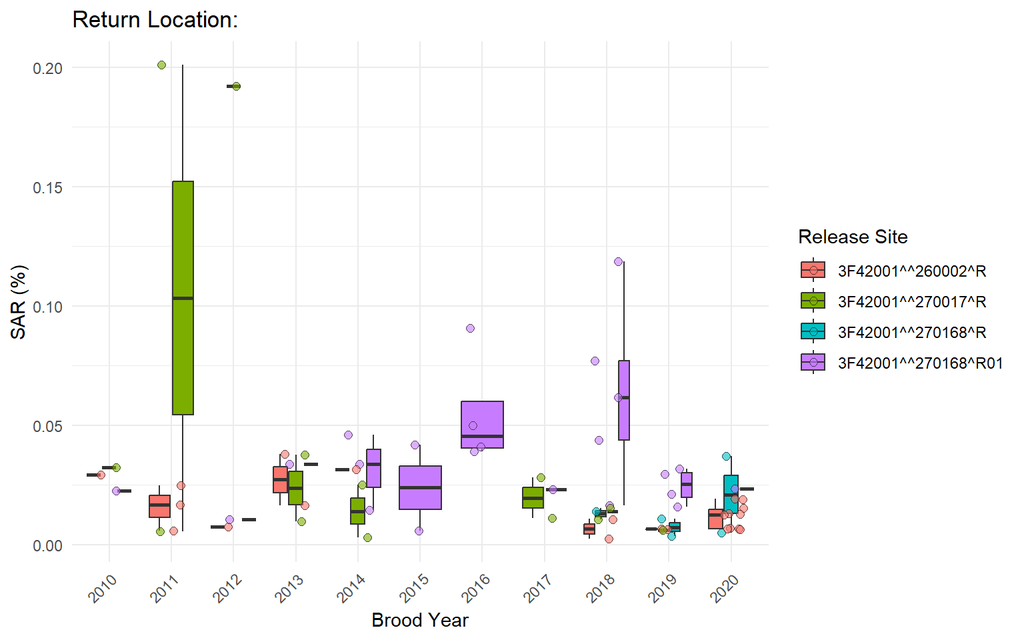

Figure 28: Smolt-adult return calcualted from the raw release and return data across brood years and release sites.

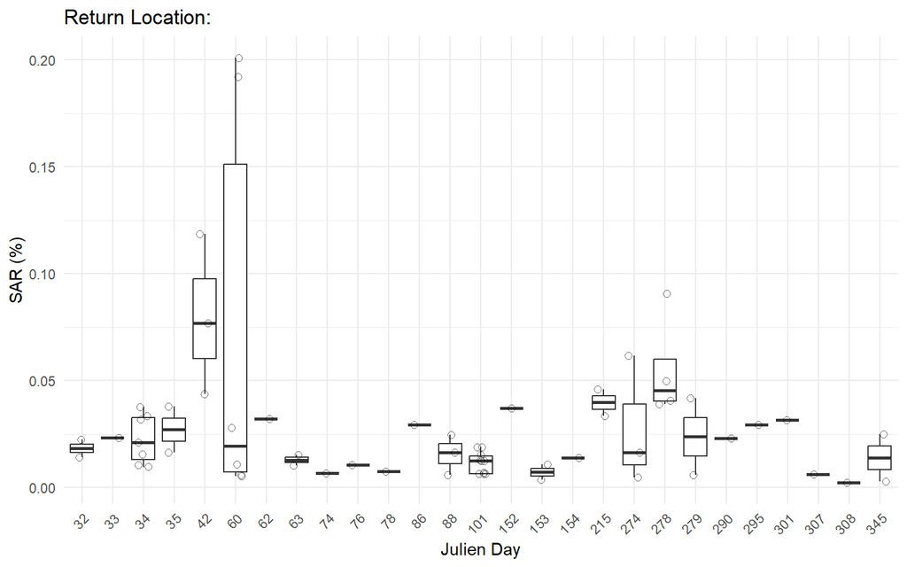

Figure 29: Smolt-adult return calcualted from the raw release and return data across brood years and julian days.

**Tab C**

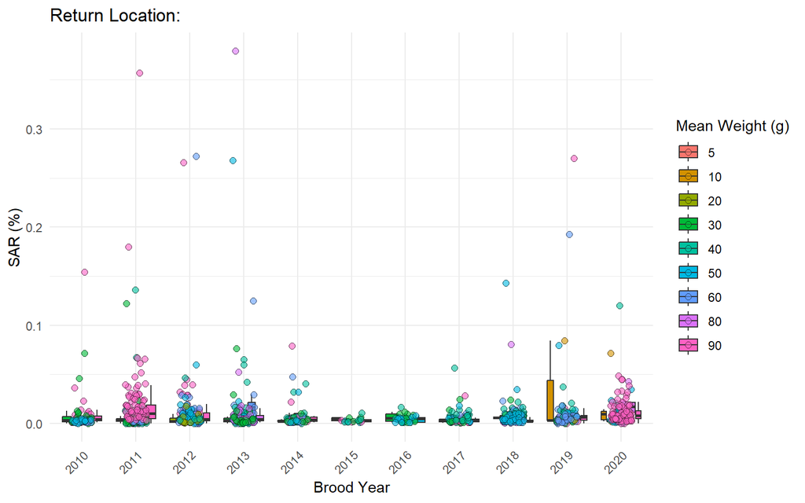

Figure 30: Smolt-adult return calcualted from the raw release and return data across brood years and mean weight release groups.

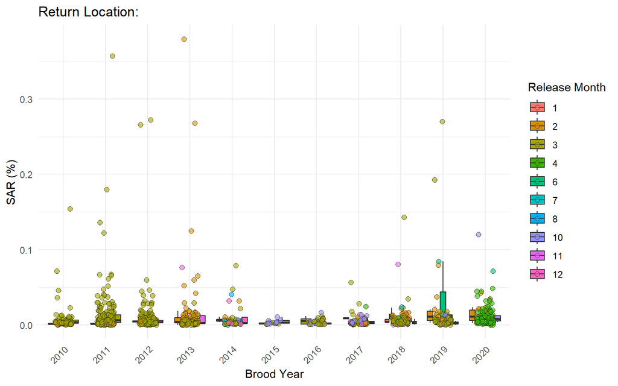

Figure 31: Smolt-adult return calcualted from the raw release and return data across brood years and release month.

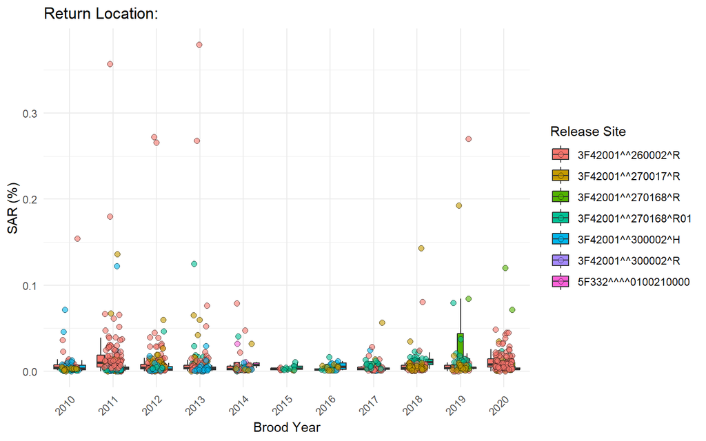

Figure 32: Smolt-adult return calcualted from the raw release and return data across brood years and release sites.

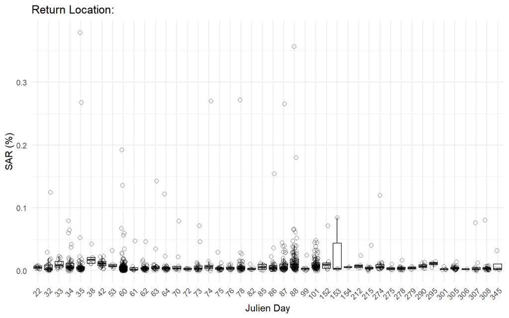

Figure 33: Smolt-adult return calcualted from the raw release and return data across brood years and julian days.

**Tab A**

Table 13: Smolt-adult return calculated across brood years, mean weight-at-release, and time at release.

| species | release_location_code | recovery_location_code | month | jday | avg_weight | event_released | sar |
| --- | --- | --- | --- | --- | --- | --- | --- |
| **2010** |  |  |  |  |  |  |  |
| 1 | 3F42001^^270168^R01 | 3F42001^^260002^H02 | 2 | 32 | 60 | 229502 | 0.0000048 |
| 1 | 3F42001^^270168^R01 | 3F42001^^270168^H | 2 | 32 | 60 | 229502 | 0.0003582 |
| 1 | 3F42001^^270168^R01 | 3F42001^^270002^H | 2 | 32 | 60 | 211944 | 0.0000047 |
| 1 | 3F42001^^270168^R01 | 3F42001^^270168^H | 2 | 32 | 60 | 211944 | 0.0003692 |
| 1 | 3F42001^^270017^R | 3F42001^^270002^H | 3 | 62 | 50 | 126231 | 0.0007535 |
| 1 | 3F42001^^270017^R | 3F42001^^270017^H | 3 | 62 | 50 | 126231 | 0.0000079 |
| 1 | 3F42001^^260002^R | 3F42001^^260002^H02 | 3 | 86 | 90 | 83600 | 0.0027159 |
| 1 | 3F42001^^260002^R | 3F42001^^270002^H | 3 | 86 | 90 | 83600 | 0.0000120 |
| **2011** |  |  |  |  |  |  |  |
| 1 | 3F42001^^270168^R01 | 3F42001^^260002^H02 | 2 | 32 | 60 | 136699 | 0.0000075 |
| 1 | 3F42001^^270168^R01 | 3F42001^^270168^H | 2 | 32 | 60 | 136699 | 0.0004869 |
| 1 | 3F42001^^270168^R01 | 3F42001^^270168^H | 2 | 32 | 60 | 133351 | 0.0005671 |
| 1 | 3F42001^^270017^R | 3F42001^^270002^H | 3 | 60 | 40 | 128155 | 0.0028647 |
| 1 | 3F42001^^270017^R | 3F42001^^270017^H | 3 | 60 | 40 | 128155 | 0.0000078 |
| 1 | 3F42001^^270017^R | 3F42001^^270168^H | 3 | 60 | 40 | 128155 | 0.0000550 |
| 1 | 3F42001^^260002^R | 3F42001^^260002^H02 | 3 | 88 | 90 | 69709 | 0.0129807 |
| 1 | 3F42001^^260002^R | 3F42001^^270002^H | 3 | 88 | 90 | 69709 | 0.0000143 |
| 1 | 3F42001^^260002^R | 3F42001^^260002^H02 | 3 | 88 | 90 | 31249 | 0.0144545 |
| **2012** |  |  |  |  |  |  |  |
| 1 | 3F42001^^270168^R01 | 3F42001^^270168^H | 2 | 34 | 40 | 44430 | 0.0002262 |
| 1 | 3F42001^^270168^R01 | 3F42001^^270168^H | 2 | 34 | 40 | 43892 | 0.0002515 |
| 1 | 3F42001^^270168^R01 | 3F42001^^270168^H | 2 | 34 | 60 | 44679 | 0.0000224 |
| 1 | 3F42001^^270168^R01 | 3F42001^^270168^H | 2 | 34 | 60 | 44554 | 0.0000676 |
| 1 | 3F42001^^270168^R01 | 3F42001^^270168^H | 3 | 62 | 40 | 42111 | 0.0004049 |
| 1 | 3F42001^^270168^R01 | 3F42001^^270168^H | 3 | 62 | 40 | 42172 | 0.0005470 |
| 1 | 3F42001^^270017^R | 3F42001^^260002^H02 | 3 | 60 | 50 | 74300 | 0.0000151 |
| 1 | 3F42001^^270017^R | 3F42001^^270002^H | 3 | 60 | 50 | 74300 | 0.0008249 |
| 1 | 3F42001^^260002^R | 3F42001^^260002^H02 | 3 | 78 | 60 | 98393 | 0.0078878 |
| 1 | 3F42001^^260002^R | 3F42001^^270168^H | 3 | 78 | 60 | 98393 | 0.0000103 |

[output cut: 163 more lines]

**Tab B**

Table 14: Smolt-adult return calculated across brood years, mean weight-at-release, and time at release.

| species | release_location_code | recovery_location_code | month | jday | avg_weight | event_released | sar |
| --- | --- | --- | --- | --- | --- | --- | --- |
| **2010** |  |  |  |  |  |  |  |
| 1 | 3F42001^^270168^R01 | 3F42001^^270168^R01 | 2 | 32 | 60 | 229502 | 0.0002238 |
| 1 | 3F42001^^270017^R | 3F42001^^270002^R | 3 | 62 | 50 | 126231 | 0.0003216 |
| 1 | 3F42001^^260002^R | 3F42001^^260002^R | 3 | 86 | 90 | 83600 | 0.0002928 |
| **2011** |  |  |  |  |  |  |  |
| 1 | 3F42001^^270017^R | 3F42001^^260002^R | 3 | 60 | 40 | 128155 | 0.0000538 |
| 1 | 3F42001^^270017^R | 3F42001^^270002^R | 3 | 60 | 40 | 128155 | 0.0020101 |
| 1 | 3F42001^^260002^R | 3F42001^^260002^R | 3 | 88 | 90 | 69709 | 0.0002473 |
| 1 | 3F42001^^260002^R | 3F42001^^270002^R | 3 | 88 | 90 | 69709 | 0.0000584 |
| 1 | 3F42001^^260002^R | 3F42001^^260002^R | 3 | 88 | 90 | 31249 | 0.0001654 |
| **2012** |  |  |  |  |  |  |  |
| 1 | 3F42001^^270168^R01 | 3F42001^^270168^R | 2 | 34 | 40 | 44430 | 0.0001060 |
| 1 | 3F42001^^270017^R | 3F42001^^270002^R | 3 | 60 | 50 | 74300 | 0.0019209 |
| 1 | 3F42001^^260002^R | 3F42001^^260002^R | 3 | 78 | 60 | 98393 | 0.0000753 |
| **2013** |  |  |  |  |  |  |  |
| 1 | 3F42001^^270168^R01 | 3F42001^^270168^R | 2 | 34 | 40 | 47259 | 0.0003367 |
| 1 | 3F42001^^270017^R | 3F42001^^270002^R | 2 | 34 | 40 | 48431 | 0.0003758 |
| 1 | 3F42001^^270017^R | 3F42001^^270002^R | 2 | 34 | 40 | 52677 | 0.0000964 |
| 1 | 3F42001^^260002^R | 3F42001^^260002^R | 2 | 35 | 50 | 94949 | 0.0003795 |
| 1 | 3F42001^^260002^R | 3F42001^^260002^R | 2 | 35 | 80 | 95258 | 0.0001636 |
| **2014** |  |  |  |  |  |  |  |
| 1 | 3F42001^^270168^R01 | 3F42001^^270168^R | 2 | 32 | 60 | 58276 | 0.0001433 |
| 1 | 3F42001^^270168^R01 | 3F42001^^270168^R | 8 | 215 | 40 | 73182 | 0.0003364 |
| 1 | 3F42001^^270168^R01 | 3F42001^^270168^R | 8 | 215 | 40 | 72782 | 0.0004589 |
| 1 | 3F42001^^260002^R | 3F42001^^260002^R | 10 | 301 | 30 | 98431 | 0.0003149 |
| 1 | 3F42001^^270017^R | 3F42001^^270002^R | 12 | 345 | 50 | 100525 | 0.0000291 |
| 1 | 3F42001^^270017^R | 3F42001^^270168^R | 12 | 345 | 50 | 100525 | 0.0002492 |
| **2015** |  |  |  |  |  |  |  |
| 1 | 3F42001^^270168^R01 | 3F42001^^270168^R | 10 | 279 | 30 | 46852 | 0.0004179 |
| 1 | 3F42001^^270168^R01 | 3F42001^^270168^R | 10 | 279 | 30 | 47223 | 0.0000582 |
| **2016** |  |  |  |  |  |  |  |
| 1 | 3F42001^^270168^R01 | 3F42001^^270168^R | 10 | 278 | 40 | 47929 | 0.0009076 |
| 1 | 3F42001^^270168^R01 | 3F42001^^270168^R | 10 | 278 | 40 | 47929 | 0.0004085 |
| 1 | 3F42001^^270168^R01 | 3F42001^^270168^R | 10 | 278 | 40 | 99317 | 0.0003900 |
| 1 | 3F42001^^270168^R01 | 3F42001^^270168^R | 10 | 278 | 40 | 99317 | 0.0004980 |
| **2017** |  |  |  |  |  |  |  |
| 1 | 3F42001^^270017^R | 3F42001^^270002^R | 3 | 60 | 40 | 124057 | 0.0001096 |
| 1 | 3F42001^^270017^R | 3F42001^^270168^R | 3 | 60 | 40 | 124057 | 0.0002805 |
| 1 | 3F42001^^270168^R01 | 3F42001^^270168^R | 10 | 290 | 40 | 37733 | 0.0002300 |
| **2018** |  |  |  |  |  |  |  |
| 1 | 3F42001^^270168^R01 | 3F42001^^270168^R | 2 | 42 | 40 | 35585 | 0.0011853 |
| 1 | 3F42001^^270168^R01 | 3F42001^^270168^R | 2 | 42 | 60 | 34049 | 0.0004373 |
| 1 | 3F42001^^270168^R01 | 3F42001^^270168^R | 2 | 42 | 60 | 33981 | 0.0007687 |
| 1 | 3F42001^^260002^R | 3F42001^^260002^R | 3 | 76 | 50 | 99327 | 0.0001063 |
| 1 | 3F42001^^270017^R | 3F42001^^270002^R | 3 | 63 | 50 | 120734 | 0.0001044 |
| 1 | 3F42001^^270017^R | 3F42001^^270168^R | 3 | 63 | 50 | 120734 | 0.0001535 |
| 1 | 3F42001^^270168^R | 3F42001^^270168^R | 6 | 154 | 5 | 50383 | 0.0001383 |
| 1 | 3F42001^^270168^R01 | 3F42001^^270168^R | 10 | 274 | 40 | 32997 | 0.0006170 |
| 1 | 3F42001^^270168^R01 | 3F42001^^270168^R | 10 | 274 | 40 | 33193 | 0.0001648 |
| 1 | 3F42001^^260002^R | 3F42001^^260002^R | 11 | 308 | 80 | 144376 | 0.0000242 |
| **2019** |  |  |  |  |  |  |  |
| 1 | 3F42001^^270168^R01 | 3F42001^^270168^R | 2 | 34 | 40 | 34886 | 0.0001568 |
| 1 | 3F42001^^270168^R01 | 3F42001^^270168^R | 2 | 34 | 40 | 35077 | 0.0002118 |
| 1 | 3F42001^^270168^R01 | 3F42001^^270168^R | 2 | 34 | 50 | 34339 | 0.0003186 |
| 1 | 3F42001^^270017^R | 3F42001^^270168^R | 3 | 60 | 60 | 124901 | 0.0000595 |
| 1 | 3F42001^^260002^R | 3F42001^^260002^R | 3 | 74 | 90 | 95824 | 0.0000664 |
| 1 | 3F42001^^270168^R | 3F42001^^270168^R | 6 | 153 | 10 | 50822 | 0.0001076 |
| 1 | 3F42001^^270168^R | 3F42001^^270168^R | 6 | 153 | 10 | 50827 | 0.0000360 |
| 1 | 3F42001^^270168^R01 | 3F42001^^270168^R | 10 | 295 | 40 | 37210 | 0.0002940 |
| 1 | 3F42001^^260002^R | 3F42001^^260002^R | 11 | 307 | 30 | 101528 | 0.0000626 |
| **2020** |  |  |  |  |  |  |  |
| 1 | 3F42001^^270168^R01 | 3F42001^^270168^R | 2 | 33 | 60 | 31832 | 0.0002334 |
| 1 | 3F42001^^260002^R | 3F42001^^260002^R | 4 | 101 | 90 | 40314 | 0.0001526 |
| 1 | 3F42001^^260002^R | 3F42001^^260002^R | 4 | 101 | 90 | 49303 | 0.0001892 |
| 1 | 3F42001^^260002^R | 3F42001^^260002^R | 4 | 101 | 90 | 45839 | 0.0000694 |
| 1 | 3F42001^^260002^R | 3F42001^^260002^R | 4 | 101 | 90 | 49358 | 0.0000644 |
| 1 | 3F42001^^260002^R | 3F42001^^260002^R | 4 | 101 | 90 | 49425 | 0.0000643 |
| 1 | 3F42001^^260002^R | 3F42001^^260002^R | 4 | 101 | 90 | 49063 | 0.0001902 |
| 1 | 3F42001^^260002^R | 3F42001^^260002^R | 4 | 101 | 90 | 49214 | 0.0001292 |
| 1 | 3F42001^^260002^R | 3F42001^^260002^R | 4 | 101 | 90 | 48800 | 0.0001260 |
| 1 | 3F42001^^260002^R | 3F42001^^260002^R | 4 | 101 | 90 | 49123 | 0.0001252 |
| 1 | 3F42001^^260002^R | 3F42001^^260002^R | 4 | 101 | 90 | 49117 | 0.0000647 |
| 1 | 3F42001^^270168^R | 3F42001^^270168^R | 6 | 152 | 10 | 45014 | 0.0003710 |
| 1 | 3F42001^^270168^R | 3F42001^^270168^R | 10 | 274 | 40 | 38327 | 0.0000480 |

**Tab C**

Table 15: Smolt-adult return calculated across brood years, mean weight-at-release, and time at release.

| species | release_location_code | recovery_location_code | month | jday | avg_weight | event_released | sar |
| --- | --- | --- | --- | --- | --- | --- | --- |
| **2010** |  |  |  |  |  |  |  |
| 1 | 3F42001^^270168^R01 | 5F33209^^R3^^^^^13 | 2 | 32 | 60 | 229502 | 0.0000096 |
| 1 | 3F42001^^270168^R01 | 5F33209^^R4^^^^^13 | 2 | 32 | 60 | 229502 | 0.0000176 |
| 1 | 3F42001^^270168^R01 | 5F33203^^R110^^^12 | 2 | 32 | 60 | 229502 | 0.0000183 |
| 1 | 3F42001^^270168^R01 | 5F33203^^R203^^^12 | 2 | 32 | 60 | 229502 | 0.0000183 |
| 1 | 3F42001^^270168^R01 | 5F33203^^R205^^^12 | 2 | 32 | 60 | 229502 | 0.0000261 |
| 1 | 3F42001^^270168^R01 | 1M1NW113^45 | 2 | 32 | 60 | 229502 | 0.0000161 |
| 1 | 3F42001^^270168^R01 | 2MN06P101^^^^^^^000 | 2 | 32 | 60 | 229502 | 0.0000219 |
| 1 | 3F42001^^270168^R01 | 3M32303 | 2 | 32 | 60 | 229502 | 0.0000260 |
| 1 | 3F42001^^270168^R01 | 5F33207^^R7^^^^^13 | 2 | 32 | 60 | 211944 | 0.0000117 |
| 1 | 3F42001^^270168^R01 | 7M1^^47N^125W | 2 | 32 | 60 | 211944 | 0.0000124 |
| 1 | 3F42001^^270168^R01 | 3M32404 | 2 | 32 | 60 | 211944 | 0.0000052 |
| 1 | 3F42001^^300002^H | 5F33207^^R7^^^^^13 | 3 | 73 | 30 | 143487 | 0.0000325 |
| 1 | 3F42001^^300002^H | 5F33209^^R1^^^^^13 | 3 | 73 | 30 | 143487 | 0.0000112 |
| 1 | 3F42001^^300002^H | 5F33209^^R2^^^^^13 | 3 | 73 | 30 | 143487 | 0.0000245 |
| 1 | 3F42001^^300002^H | 5F33209^^R3^^^^^13 | 3 | 73 | 30 | 143487 | 0.0000153 |
| 1 | 3F42001^^300002^H | 5F33209^^R4^^^^^13 | 3 | 73 | 30 | 143487 | 0.0000170 |
| 1 | 3F42001^^300002^H | 5F33209^^R5^^^^^13 | 3 | 73 | 30 | 143487 | 0.0000112 |
| 1 | 3F42001^^300002^H | 5F33406^^R6^^^^^13 | 3 | 73 | 30 | 143487 | 0.0007172 |
| 1 | 3F42001^^300002^H | 5F33203^^R101^^^12 | 3 | 73 | 30 | 143487 | 0.0001005 |
| 1 | 3F42001^^300002^H | 5F33203^^R102^^^12 | 3 | 73 | 30 | 143487 | 0.0000417 |
| 1 | 3F42001^^300002^H | 5F33203^^R104^^^12 | 3 | 73 | 30 | 143487 | 0.0000709 |
| 1 | 3F42001^^300002^H | 5F33203^^R105^^^12 | 3 | 73 | 30 | 143487 | 0.0001250 |
| 1 | 3F42001^^300002^H | 5F33203^^R108^^^12 | 3 | 73 | 30 | 143487 | 0.0000774 |
| 1 | 3F42001^^300002^H | 5F33203^^R110^^^12 | 3 | 73 | 30 | 143487 | 0.0000355 |
| 1 | 3F42001^^300002^H | 5F33203^^R201^^^12 | 3 | 73 | 30 | 143487 | 0.0000590 |
| 1 | 3F42001^^300002^H | 5F33203^^R202^^^12 | 3 | 73 | 30 | 143487 | 0.0001129 |
| 1 | 3F42001^^300002^H | 5F33203^^R203^^^12 | 3 | 73 | 30 | 143487 | 0.0000294 |
| 1 | 3F42001^^300002^H | 5F33203^^R205^^^12 | 3 | 73 | 30 | 143487 | 0.0000293 |
| 1 | 3F42001^^300002^H | 5F33203^^R207^^^12 | 3 | 73 | 30 | 143487 | 0.0000417 |

[output cut: 1092 more lines]

SAR Model Fit

SAR time series are then fit to generalized additive models to summarize trends and identify any potentially significant release treatments. There are a variety of methods that can be employed for summarizing and forecasting SAR. A simple form of this would entail fitting a generalized additive model to the time series of SAR data. Here, we fit generalized additive models assuming a quasi-binomial family and a logit link function to the time series of two components of the smolt-adult-return data: total tags released & total tags lost. Models employed brood year, weight-at-release, and julian day as main effects (release stage, hatchery, & release location coming soon), as well as two-way interactions among these.After model fitting, figures are generated to show the results of the SAR calculations and the selected model fit, including marginal effects.